# UCI Leaf Analysis

hbmaclean

2025-07-25

# 1 Introduction

This analysis primarily serves to keep me learning. I chose this data set as somewhat of an amateur botanist; I recognize most of the 40 listed genus names. I seem to be in unchartered territory though as the [data description](https://archive.ics.uci.edu/dataset/288/leaf) does not have any citations or baseline model performance (unlike [mushrooms](https://archive.ics.uci.edu/dataset/73/mushroom) for example.)

Glancing at the data, I’m in for a challenge as the features are all doubles with very fine precision. There is no obvious way of transforming the data such that it can be meaningfully grouped. Here goes…

# 2 Data Creation

This downloads the zip; extracts the data file; reads and parses the lines into a `data.frame`; converts to numeric; and adds column names.

```r
fetch_data <- function(verbose=FALSE) {
    options(timeout = 120)
    tmp   <- tempfile()
    zip   <- "https://archive.ics.uci.edu/static/public/288/leaf.zip"

    download.file(zip, tmp, quiet = !verbose)
    data <- as.data.frame(
        str_split(
            read_lines(
                unz(tmp, "leaf.csv")
            ),
            ",",
            simplify=TRUE
        )
    ) |> mutate(across(everything(), ~ as.double(.x)))

    colnames(data) <- c(
        'Species', 'SpecimenNumber', 'Eccentricity', 'AspectRatio',
        'Elongation', 'Solidity', 'StochasticConvexity',
        'IsoperimetricFactor', 'MaxIndentationDepth', 'Lobedness',
        'AverageIntensity', 'AverageContrast', 'Smoothness',
        'ThirdMoment', 'Uniformity', 'Entropy'
    )

    return(data)
}

leaf_df <- fetch_data()
```

Currently the row names are equivalent to SpecimenNumber. The trees’ genus and species are provided separately. Here I glue together new row names with genus, species, and specimen number.

I then drop SpecimenNumber, which surely is just metadata without predictive power.

```r
names <- c(
    '1' = 'Quercus suber', '2' = 'Salix atrocinerea', '3' = 'Populus nigra',
    '4' = 'Alnus sp', '5' = 'Quercus robur', '6' = 'Crataegus monogyna',
    '7' = 'Ilex aquifolium', '8' = 'Nerium oleander', '9' = 'Betula pubescens',
    '10' = 'Tilia tomentosa', '11' = 'Acer palmaturu', '12' = 'Celtis sp',
    '13' = 'Corylus avellana', '14' = 'Castanea sativa', '15' = 'Populus alba',
    '22' = 'Primula vulgaris', '23' = 'Erodium sp', '24' = 'Bougainvillea sp',
    '25' = 'Arisarum vulgare', '26' = 'Euonymus japonicus', '27' = 'Ilex perado ssp azorica',
    '28' = 'Magnolia soulangeana', '29' = 'Buxus sempervirens', '30' = 'Urtica dioica',
    '31' = 'Podocarpus sp', '32' = 'Acca sellowiana', '33' = 'Hydrangea sp',
    '34' = 'Pseudosasa japonica', '35' = 'Magnolia grandiflora', '36' = 'Geranium sp'
)
rownames(leaf_df) <- paste(names[as.character(leaf_df$Species)], rownames(leaf_df))
leaf_df$SpecimenNumber <- NULL
```

## 2.1 Data Sample

Now for a sample. Note, I’ve struggled with the lengthy column names as a header row. Clearly cells are vertically centered by default; and evidently `'vertical-align:bottom'` is ineffective in `row_spec`. It can be accomplished with `cell_spec`, but that renders a raw HTML span tag in the cell. I’ve done my best here to accommodate PDF and HTML. (Worth noting, PDF rotates `angle` *counterclockwise*.)

```r
slice_sample(leaf_df[,2:15], n = 5) |>
    knitr::kable(digits = 2, align = 'c', caption = 'UCI Leaf Sample') |>
    kable_styling(bootstrap_options = 'bordered') |>
    row_spec(
        0,
        angle = -60,
        extra_css = 'column-width: 2px; line-height: 100px; vertical-align:top; opacity: .5'
    ) |>
    column_spec(1, bold = TRUE)
```

UCI Leaf Sample

|  | Eccentricity | AspectRatio | Elongation | Solidity | StochasticConvexity | IsoperimetricFactor | MaxIndentationDepth | Lobedness | AverageIntensity | AverageContrast | Smoothness | ThirdMoment | Uniformity | Entropy |
| --- | --- | --- | --- | --- | --- | --- | --- | --- | --- | --- | --- | --- | --- | --- |
| Magnolia grandiflora 324 | 0.92 | 2.67 | 0.63 | 0.98 | 1.00 | 0.52 | 0.02 | 0.06 | 0.10 | 0.18 | 0.03 | 0.01 | 0 | 1.97 |
| Populus alba 167 | 0.38 | 1.07 | 0.52 | 0.72 | 0.85 | 0.26 | 0.07 | 0.78 | 0.07 | 0.14 | 0.02 | 0.01 | 0 | 1.85 |
| Celtis sp 129 | 0.93 | 2.82 | 0.66 | 0.93 | 0.98 | 0.44 | 0.05 | 0.39 | 0.05 | 0.13 | 0.02 | 0.01 | 0 | 1.40 |
| Hydrangea sp 299 | 0.61 | 1.39 | 0.30 | 0.97 | 1.00 | 0.74 | 0.01 | 0.02 | 0.14 | 0.21 | 0.04 | 0.01 | 0 | 2.27 |
| Urtica dioica 270 | 0.19 | 1.06 | 0.25 | 0.94 | 0.99 | 0.47 | 0.02 | 0.07 | 0.06 | 0.13 | 0.02 | 0.00 | 0 | 1.41 |

# 3 Class Distribution

First, I set expectations with class distribution - which appears to be fairly uniform other than ten unrepresented species:

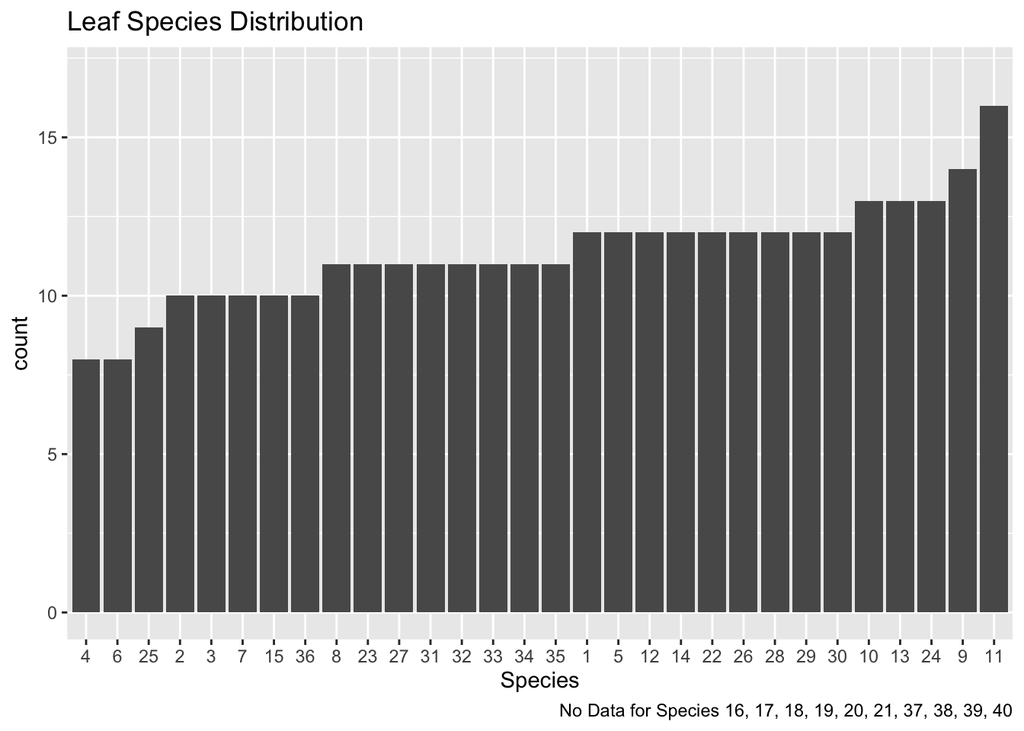

```r
leaf_df |>
    group_by(Species) |>
    mutate(n = n()) |>
    ungroup() |>
    mutate(Species = reorder(factor(Species), n)) |>
    ggplot(aes(Species)) +
    geom_bar() +
    scale_y_continuous(limits = c(0,17)) +
    labs(
        title   = 'Leaf Species Distribution',
        caption = sprintf(
            'No Data for Species %s',
            paste(setdiff(1:40, unique(leaf_df$Species)), collapse = ', ')
        )
    )
```

# 4 Dimension Reduction

## 4.1 Near-Zero Variance

Contrary to near-zero variance, this data is nearly 100% variable!

```r
leaf_df |> dplyr::select(-c(Species)) |>
    summarise_all(n_distinct) |>
    pivot_longer(everything(), names_to = 'Column', values_to = 'N_Distinct') |>
    mutate(Variability = N_Distinct/nrow(leaf_df) * 100) |>
    arrange(desc(N_Distinct)) |>
    knitr::kable(digits = 2, align = 'l') |>
    kable_styling(bootstrap_options = 'bordered')
```

| Column | N_Distinct | Variability |
| --- | --- | --- |
| MaxIndentationDepth | 340 | 100.00 |
| ThirdMoment | 340 | 100.00 |
| Eccentricity | 339 | 99.71 |
| Elongation | 339 | 99.71 |
| IsoperimetricFactor | 339 | 99.71 |
| Lobedness | 339 | 99.71 |
| AverageContrast | 339 | 99.71 |
| Smoothness | 339 | 99.71 |
| Uniformity | 339 | 99.71 |
| AverageIntensity | 338 | 99.41 |
| Entropy | 337 | 99.12 |
| AspectRatio | 334 | 98.24 |
| Solidity | 333 | 97.94 |
| StochasticConvexity | 88 | 25.88 |

## 4.2 Principal Component Analysis

This is promising - four PCs explain 90% of the variance; and thus `pca` should be a useful `preProcess` option for `train`.

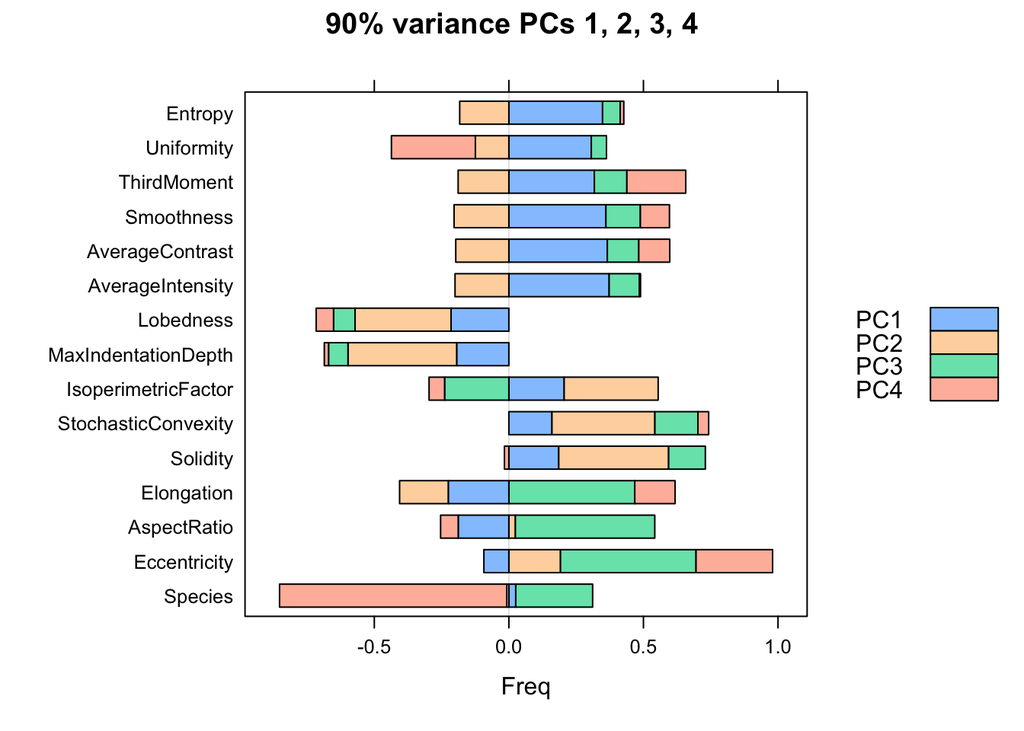

```r
pca <- prcomp(leaf_df, scale = TRUE)
PCs <- which(cumsum(pca$sdev^2)/sum(pca$sdev^2) < 0.90)
barchart(
    pca$rotation[,1:length(PCs)],
    auto.key = TRUE,
    main = sprintf(
        '90%% variance PCs %s',
        paste(PCs, collapse = ', ')
    )
)
```

## 4.3 Correlation

First, a hand-rolled look at correlation, having noticed that `dplyr` has `lag`, `lead`, and other functions analogous to familiar Oracle analytic functions. Here I look for columns with 75%+ correlation and use `lag` to filter out “duplicate” rows of a X/Y and Y/X correlations.

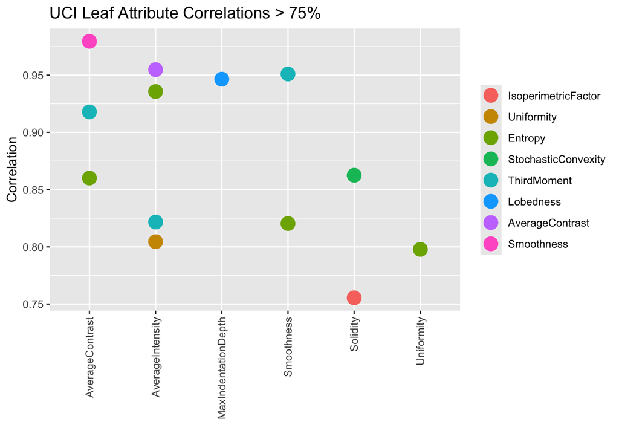

```r
cor(leaf_df) |>
    as.data.frame() |>
    rownames_to_column(var = 'X') |>
    pivot_longer(cols = -c(1), names_to = 'Y', values_to = 'Correlation') |>
    arrange(desc(Correlation)) |>
    filter(X != Y & Y != lag(X) & Correlation > .75) |>
    mutate(Y = reorder(factor(Y), Correlation)) |>
    ggplot(aes(X, Correlation, fill = Y)) +
    theme(
        axis.text.x  = element_text(angle = 90, vjust = 0.5, hjust=1),
        legend.title = element_blank()
    ) +
    geom_point(aes(color = Y), size = 5) +
    labs(x = '', title = 'UCI Leaf Attribute Correlations > 75%')
```

### 4.3.1 GGPAIRS

With that, I look at the correlations from both directions - first the columns on the x-axis (plus Species, the outcome):

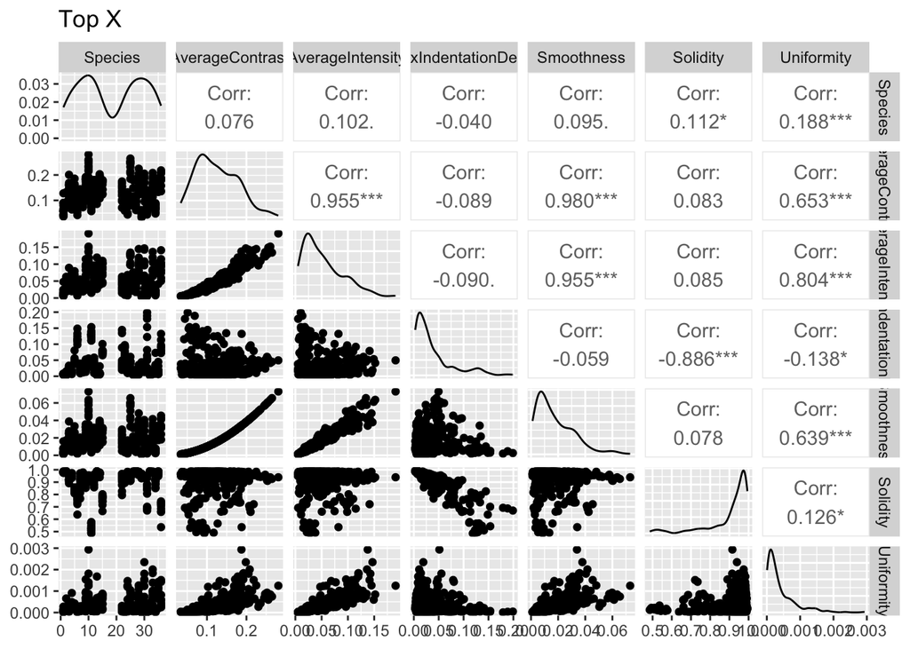

```r
top_x <- c(
    'Species', 'AverageContrast', 'AverageIntensity',
    'MaxIndentationDepth', 'Smoothness', 'Solidity', 'Uniformity'
)
ggpairs(leaf_df[,top_x]) + ggtitle('Top X')
```

Note, explained [here](https://ggobi.github.io/ggally/reference/ggally_cor.html), the meaning of asterisks in `ggpairs` plots:

- `***` indicates p-value < 0.001
- `**` indicates p-value < 0.01
- `*` indicates p-value < 0.05

And now the columns on the y-axis (again, plus Species).

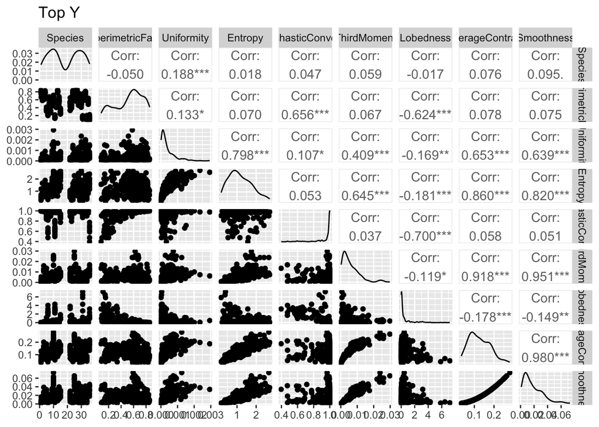

```r
top_y <- c(
    'Species', 'IsoperimetricFactor', 'Uniformity', 'Entropy', 'StochasticConvexity',
    'ThirdMoment', 'Lobedness', 'AverageContrast', 'Smoothness'
)
ggpairs(leaf_df[,top_y]) + ggtitle('Top Y')
```

See also `?ggpairs` and [this blog](https://www.blopig.com/blog/2019/06/a-brief-introduction-to-ggpairs/) for customizing `ggpairs` plots. Also note, these do not plot together with `grid.arrange`. They can be plotted together with `cowplot::plot_grid`, but do not render very well.

### 4.3.2 GGCORRPLOT

This plot is the clearest to me.

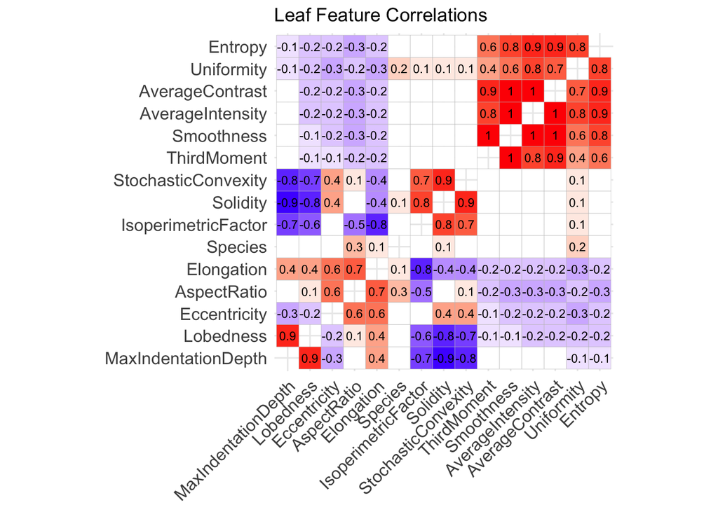

```r
leaf_correlations <- function(df) {
    p.mat <- cor_pmat(df)   # matrix of correlation p-values
    ggcorrplot(
        cor(df),
        hc.order    = TRUE,     # reorder layout with hierarchical clustering
        hc.method   = 'median', # see ?hclust for other methods
        lab         = TRUE,     # adds correlation coefficients
        lab_size    = 3,
        digits      = 1,
        show.diag   = FALSE,    # omits self-correlation diagonal
        p.mat       = p.mat,    # p-values
        sig.level   = 0.001,    # p-value threshold
        insig       = 'blank',  # omits correlations with p-values below threshold
        show.legend = FALSE,
        title       = 'Leaf Feature Correlations'
    )
}
leaf_correlations(leaf_df)
```

Below, I’ve extracted absolute correlations of .9 and 1:

Strong Correlations, Low P-Values

|  | Correlation |
| --- | --- |
| **Entropy** |  |
| AverageIntensity | 0.9 |
| AverageContrast | 0.9 |
| **AverageContrast** |  |
| Smoothness | 1.0 |
| AverageIntensity | 1.0 |
| ThirdMoment | 0.9 |
| Entropy | 0.9 |
| **AverageIntensity** |  |
| Smoothness | 1.0 |
| AverageContrast | 1.0 |
| Entropy | 0.9 |
| **Smoothness** |  |
| ThirdMoment | 1.0 |
| AverageIntensity | 1.0 |
| AverageContrast | 1.0 |
| **ThirdMoment** |  |
| Smoothness | 1.0 |
| AverageContrast | 0.9 |
| **StochasticConvexity** |  |
| Solidity | 0.9 |
| **Solidity** |  |
| StochasticConvexity | 0.9 |
| MaxIndentationDepth | -0.9 |
| **Lobedness** |  |
| MaxIndentationDepth | 0.9 |

Conclusions from this:

1. Smoothness has a 1:1 correlation with ThirdMoment, AverageIntensity, and AverageContrast, and so those three can be confidently omitted.
2. Aside from those, the following pairs have .9 correlation: Solidity/StochasticConvexity and Lobedness/MaxIndentationDepth. Note also, Solidity has a -0.9 correlation with MaxIndentationDepth. I’ll keep the two shorter-named columns and omit MaxIndentationDepth and StochasticConvexity.
3. `corr` should be an effective `preProcess` option for `train`.

# 5 Partition Data

Prior to testing, halve the data into train and test partitions.

```r
index <- createDataPartition(y = leaf_df$Species, times = 1, p = 0.5, list = FALSE)
train <- leaf_df[index,]
test  <- leaf_df[-index,]
```

# 6 Baseline Models

Given 40 30 fairly evenly distributed species, the odds of guessing would be about 0.0333. Somewhat arbitrarily, I have chosen `lm`, `ranger`, and `randomForest`. Knowing I will run each in numerous scenarios and want to capture the metrics, I first define some repeatable functions and a `tibble` for tracking.

First, methods for predicting and calculating RMSE and accuracy:

```r
predictions <- function(model, test) {
    # TODO: handle this more elegantly with ellipsis operator
    if (class(model)[1] == 'lm') {
        pred <- predict(model, test, type = 'response')
    }
    else {
        pred <- predict(model, test)
    }
    if (is.atomic(pred)) {
        predictions <- pred
    }
    else {
         predictions <- pred$predictions
    }
    predictions
}

rmse <- function(model, test) {
    predictions <- predictions(model, test)
    rmse <- sqrt(mean((predictions-test$Species)^2))
    round(rmse, 3)
}

accuracy <- function(model, test) {
    predictions <- predictions(model, test)
    cm   <- confusionMatrix(predictions, factor(test$Species))
    round(100*cm$overall[['Accuracy']], 3)
}
```

Now repeatable methods for the models.

```r
lm__ <- function(train, test, formula = as.formula(Species ~ .)) {
    fit <- lm(formula, train)
    rmse(fit, test)
}

ranger__r <- function(train, test, formula = as.formula(Species ~ .)) {
    fit <- ranger(formula, train)
    rmse(fit, test)
}

ranger__c <- function(train, test, formula = as.formula(factor(Species) ~ .)) {
    fit <- ranger(formula, train)
    accuracy(fit, test)
}

rf__r <- function(train, test, formula = as.formula(Species ~ .)) {
    fit <- randomForest(formula, train, ntree = 20)
    rmse(fit, test)
}

rf__c <- function(train, test, formula = as.formula(factor(Species) ~ .)) {
    fit <- randomForest(formula, train, ntree = 20)
    accuracy(fit, test)
}
```

Finally, a `tibble` for tracking and methods for displaying it.

```r
model_results <- tibble(
    Model    = character(),
    RMSE     = double(),
    Accuracy = double()
)

rows_per <- function() { as.integer(nrow(model_results)/3) }

model_summary <- function() {
    n <- rows_per()
    knitr::kable(model_results, align = c('l', 'r', 'r'), digits = 3) |>
    kable_styling(bootstrap_options = 'bordered') |>
    pack_rows(index = c(lm = n, ranger = n, randomForest = n), background = 'grey') |>
    add_header_above(c(' ', 'Regression' = 1, 'Classification' = 1), align = 'r')
}
```

Now I run the three models and capture their RMSE/Accuracy metrics.

```r
model_results <- model_results |> add_row(
    tibble_row(
        Model    = 'baseline',
        RMSE     = lm__(train, test),
        Accuracy = NULL
    )
)
model_results <- model_results |> add_row(
    tibble_row(
        Model    = 'baseline',
        RMSE     = ranger__r(train, test),
        Accuracy = ranger__c(train, test)
    )
)
model_results <- model_results |> add_row(
    tibble_row(
        Model    = 'baseline',
        RMSE     = rf__r(train, test),
        Accuracy = rf__c(train, test)
    )
)

model_summary()
```

| Model | Regression RMSE | Classification Accuracy |
| --- | --- | --- |
| **lm** |  |  |
| baseline | 10.212 | NA |
| **ranger** |  |  |
| baseline | 8.054 | 71.006 |
| **randomForest** |  |  |
| baseline | 8.066 | 69.231 |

# 7 Centering

Centering the data is often recommended; let us see the effect.

```r
train_ctr <- train |> mutate(across(-c(Species), ~ scale(.x, center=TRUE, scale=FALSE)))
test_ctr  <- test  |> mutate(across(-c(Species), ~ scale(.x, center=TRUE, scale=FALSE)))

model_results <- model_results |> add_row(
    tibble_row(
        Model    = 'centering',
        RMSE     = lm__(train_ctr, test_ctr),
        Accuracy = NULL
    ),
    .after = rows_per()
)
model_results <- model_results |> add_row(
    tibble_row(
        Model    = 'centering',
        RMSE     = ranger__r(train_ctr, test_ctr),
        Accuracy = ranger__c(train_ctr, test_ctr)
    ),
    .after = 2 * rows_per() + 1
)
model_results <- model_results |> add_row(
    tibble_row(
        Model    = 'centering',
        RMSE     = rf__r(train_ctr, test_ctr),
        Accuracy = rf__c(train_ctr, test_ctr)
    )
)
model_summary()
```

| Model | Regression RMSE | Classification Accuracy |
| --- | --- | --- |
| **lm** |  |  |
| baseline | 10.212 | NA |
| centering | 10.135 | NA |
| **ranger** |  |  |
| baseline | 8.054 | 71.006 |
| centering | 8.166 | 71.006 |
| **randomForest** |  |  |
| baseline | 8.066 | 69.231 |
| centering | 8.346 | 66.272 |

Inconclusive at best. I may revisit centering as a `preProcess` for `train`, with low expectations.

```r
rm(train_ctr, test_ctr)
```

# 8 Removing Highly Correlated Columns

Earlier I noted some highly correlated columns. Perhaps removing them will help. Here I use a set operation to omit them from the column list, and rerun the models.

```r
high_corr <- c(
    'ThirdMoment', 'AverageIntensity', 'AverageContrast',  # 100% with Smoothness
    'MaxIndentationDepth',                                 # 90% with Lobedness
    'StochasticConvexity'                                  # 90% with Solidity
)
cols <- setdiff(names(leaf_df), high_corr)

model_results <- model_results |> add_row(
    tibble_row(
        Model    = '<90% correlation',
        RMSE     = lm__(train[,cols], test[,cols]),
        Accuracy = NULL
    ),
    .after = rows_per()
)
model_results <- model_results |> add_row(
    tibble_row(
        Model    = '<90% correlation',
        RMSE     = ranger__r(train[,cols], test[,cols]),
        Accuracy = ranger__c(train[,cols], test[,cols])
    ),
    .after = 2 * rows_per() + 1
)
model_results <- model_results |> add_row(
    tibble_row(
        Model    = '<90% correlation',
        RMSE     = rf__r(train[,cols], test[,cols]),
        Accuracy = rf__c(train[,cols], test[,cols])
    )
)
model_summary()
```

| Model | Regression RMSE | Classification Accuracy |
| --- | --- | --- |
| **lm** |  |  |
| baseline | 10.212 | NA |
| centering | 10.135 | NA |
| <90% correlation | 10.110 | NA |
| **ranger** |  |  |
| baseline | 8.054 | 71.006 |
| centering | 8.166 | 71.006 |
| <90% correlation | 7.851 | 70.414 |
| **randomForest** |  |  |
| baseline | 8.066 | 69.231 |
| centering | 8.346 | 66.272 |
| <90% correlation | 8.515 | 66.864 |

Improvements in some cases. Worth revisiting, and comparing with `corr` option for `preProcess`.

# 9 Removing High VIF

[Evidently](https://en.wikipedia.org/wiki/Variance_inflation_factor) variance inflation factor provides a measure of collinearity. We can see the values with `vif` against an `lm` object.

```r
lm_obj <- lm(Species ~ ., train)
vif(lm_obj) |>
    as.data.table(keep.rownames = TRUE) |>
    arrange(desc(V2)) |>
    knitr::kable(col.names = c('Column', 'VIF')) |>
    kable_styling(bootstrap_options = c('bordered', 'striped', 'condensed'))
```

| Column | VIF |
| --- | --- |
| Smoothness | 2158.086725 |
| AverageIntensity | 1538.147155 |
| ThirdMoment | 335.399587 |
| Entropy | 94.472909 |
| AverageContrast | 43.922126 |
| MaxIndentationDepth | 33.870803 |
| Lobedness | 19.951121 |
| IsoperimetricFactor | 19.647158 |
| Elongation | 18.504010 |
| Uniformity | 17.031985 |
| Solidity | 15.282042 |
| Eccentricity | 7.607560 |
| StochasticConvexity | 6.287658 |
| AspectRatio | 5.496847 |

Let’s see if removing the top few makes a difference.

```r
high_vif <- vif(lm_obj) |>
    as.data.frame() |>
    rownames_to_column(var = 'Column') |>
    slice_max(pick(2), n = 3) |>
    pull(Column)
cols <- setdiff(names(train), high_vif)
```

```r
model_results <- model_results |> add_row(
    tibble_row(
        Model    = 'minus top 3 VIF',
        RMSE     = lm__(train[,cols], test[,cols]),
        Accuracy = NULL
    ),
    .after = rows_per()
)
model_results <- model_results |> add_row(
    tibble_row(
        Model    = 'minus top 3 VIF',
        RMSE     = ranger__r(train[,cols], test[,cols]),
        Accuracy = ranger__c(train[,cols], test[,cols])
    ),
    .after = 2 * rows_per() + 1
)
model_results <- model_results |> add_row(
    tibble_row(
        Model    = 'minus top 3 VIF',
        RMSE     = rf__r(train[,cols], test[,cols]),
        Accuracy = rf__c(train[,cols], test[,cols])
    )
)
model_summary()
```

| Model | Regression RMSE | Classification Accuracy |
| --- | --- | --- |
| **lm** |  |  |
| baseline | 10.212 | NA |
| centering | 10.135 | NA |
| <90% correlation | 10.110 | NA |
| minus top 3 VIF | 10.142 | NA |
| **ranger** |  |  |
| baseline | 8.054 | 71.006 |
| centering | 8.166 | 71.006 |
| <90% correlation | 7.851 | 70.414 |
| minus top 3 VIF | 7.915 | 69.231 |
| **randomForest** |  |  |
| baseline | 8.066 | 69.231 |
| centering | 8.346 | 66.272 |
| <90% correlation | 8.515 | 66.864 |
| minus top 3 VIF | 8.205 | 66.272 |

Mixed results.

# 10 Removing Outliers and Extreme Values

I happened upon `rstatix::identify_outliers`, and from there `is_outlier` and `is_extreme`. Here I experiment by nullifying such values with the intent of replacing them with `preProcess` methods `medianImpute`, `bagImpute`, and `knnImpute`.

```r
# identify and nullify outliers - other than first column, Species
train_o      <- train |> as.matrix()
outliers     <- rstatix::is_outlier(train_o)
idx          <- which(outliers[,2:15])
train_o[idx] <- NA
train_o      <- train_o |> as.data.frame()

# create second data frame with extreme values also nullified
train_x      <- train_o |> as.matrix()
xtreme       <- rstatix::is_extreme(train_x)
idx          <- which(xtreme[,2:15])
train_x[idx] <- NA
train_x      <- train_x |> as.data.frame()
```

Anxious to see the effect, I want to do some early analysis that requires no NAs! For that, I found `missMethods::impute_mean`. Note, the default implementation has `type = 'columnwise'` - which seems logical, to replace an NA with the overall mean of its column. There are also `'rowwise'`, `'total'`, ’`Winer'`, and `'Two-Way'` - see [the documentation](https://search.r-project.org/CRAN/refmans/missMethods/html/impute_mean.html) for details.

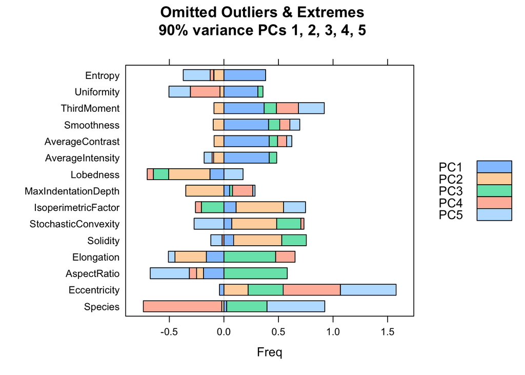

```r
imp <- impute_mean(train_x)
pca <- prcomp(imp, scale = TRUE)
PCs <- which(cumsum(pca$sdev^2)/sum(pca$sdev^2) < 0.90)
barchart(
    pca$rotation[,1:length(PCs)],
    auto.key = TRUE,
    main = sprintf(
        'Omitted Outliers & Extremes\n90%% variance PCs %s',
        paste(PCs, collapse = ', ')
    )
)
```

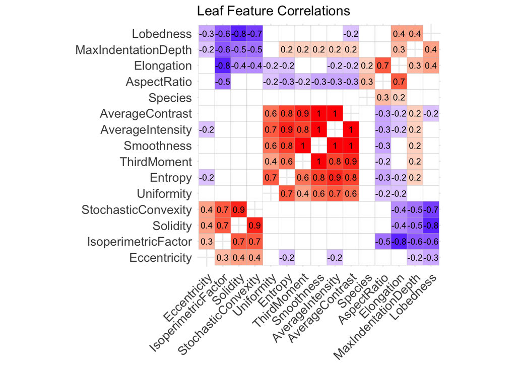

```r
leaf_correlations(imp)
```

Mean imputation added a fifth PC to explain 90% variation; and made a visible shift to the correlation plot - there are fewer correlations of .9 and 1 and 50% more white space. What might it mean for accuracy…?

# 11 Improve with train()

Perhaps we can make improvements with `train` and its `trControl`, `preProcess`, and `tuneGrid`.

First I define a `trainControl` object to be used for all.

```r
trControl <- trainControl(
    method          = 'cv',    # cross-validation
    number          = 2,       # two repetitions, atop whatever tuneGrid dictates
    p               = .5,      # 50% training portion
    savePredictions = 'final'  # train_obj$results$pred
)
```

## 11.1 train LM

```r
lm_obj <- train(
    Species ~ .,
    method     = 'lm',
    data       = train,
    trControl  = trControl,
    preProcess = c('pca', 'corr'),
    tuneGrid   = data.frame(intercept = c(TRUE, FALSE))
)

model_results <- model_results |> add_row(
    tibble_row(
        Model    = 'train()',
        RMSE     = rmse(lm_obj, test),
        Accuracy = NA
    ),
    .after = rows_per()
)
```

## 11.2 train Ranger

```r
ranger_objr <- train(
    Species ~ .,
    method     = 'ranger',
    data       = train,
    trControl  = trControl,
    preProcess = c('pca', 'corr'),
    importance = 'permutation',
    replace    = TRUE,
    tuneGrid   = expand.grid(
        mtry          = c(1,3,5),
        splitrule     = c('variance', 'extratrees', 'maxstat'),
        min.node.size = c(5,10,15)
    )
)

ranger_objc <- train(
      factor(Species) ~ .,
      method     = 'ranger',
      data       = train,
      trControl  = trControl,
      preProcess = c('pca', 'corr'),
      importance = 'permutation',
      replace    = TRUE,
      tuneGrid   = expand.grid(
          mtry          = c(1,3,5),
          splitrule     = c('gini', 'extratrees'),
          min.node.size = c(1,3)
      )
)

model_results <- model_results |> add_row(
    tibble_row(
        Model    = 'train()',
        RMSE     = rmse(ranger_objr, test),
        Accuracy = accuracy(ranger_objc, test)
    ),
    .after = 2 * rows_per() + 1
)
```

## 11.3 train RandomForest

```r
rf_objr <- train(
    Species ~ .,
    method   = 'rf',
    data     = train,
    trControl = trControl,
    preProcess = c('pca', 'corr'),
    tuneGrid   = data.frame(mtry = seq(6,10,1))
)

rf_objc <- train(
    factor(Species) ~ .,
    method     = 'rf',
    data       = train,
    trControl  = trControl,
    preProcess = c('pca', 'corr'),
    tuneGrid   = data.frame(mtry = seq(6,10,1))
)

model_results <- model_results |> add_row(
    tibble_row(
        Model    = 'train()',
        RMSE     = rmse(rf_objr, test),
        Accuracy = accuracy(rf_objc, test)
    )
)
model_summary()
```

| Model | Regression RMSE | Classification Accuracy |
| --- | --- | --- |
| **lm** |  |  |
| baseline | 10.212 | NA |
| centering | 10.135 | NA |
| <90% correlation | 10.110 | NA |
| minus top 3 VIF | 10.142 | NA |
| train() | 10.430 | NA |
| **ranger** |  |  |
| baseline | 8.054 | 71.006 |
| centering | 8.166 | 71.006 |
| <90% correlation | 7.851 | 70.414 |
| minus top 3 VIF | 7.915 | 69.231 |
| train() | 8.355 | 60.947 |
| **randomForest** |  |  |
| baseline | 8.066 | 69.231 |
| centering | 8.346 | 66.272 |
| <90% correlation | 8.515 | 66.864 |
| minus top 3 VIF | 8.205 | 66.272 |
| train() | 8.565 | 60.355 |

The results are disappointing; but there are more training options to pursue.

# 12 Further Analysis

## 12.1 RandomForest Decision Tree

The `reprtree` package enables the plotting of a randomForest decision tree, which gives insight into the model’s thinking. Note, documentation suggests that the `plot.getTree` ellipsis passes arguments to `text.tree` - but its `pretty` and `digits` arguments are quietly ineffective and `splits` gives an error. And, real estate vs resolution is challenging: setting `fig.height` improves the layout but decreases the text size; setting `depth` helps, but at the cost of lower leaf nodes.

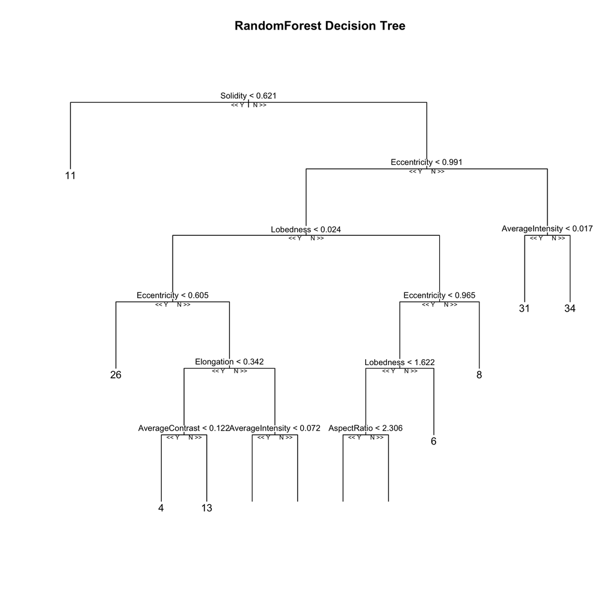

```r
fit <- randomForest(factor(Species) ~ ., train, ntree = 20)
simplest_tree <- which.min(fit$forest$ndbigtree)
fit$forest$xbestsplit <- round(fit$forest$xbestsplit, 3)  # 'digits' workaround
plot.getTree(
    fit,
    k     = simplest_tree,
    depth = 7,
    main  = 'RandomForest Decision Tree'
)
```

Trying to mimic that with `dplyr` methods would result in one dense, arbitrary-looking `if-else` condition!

## 12.2 Ranger Predictions vs Observations

Choosing ranger arbitrarily, I look at its predictions versus the actual observations. It looks uniformly off, which seems reasonable to me given the complexity and near-complete variability of the data.

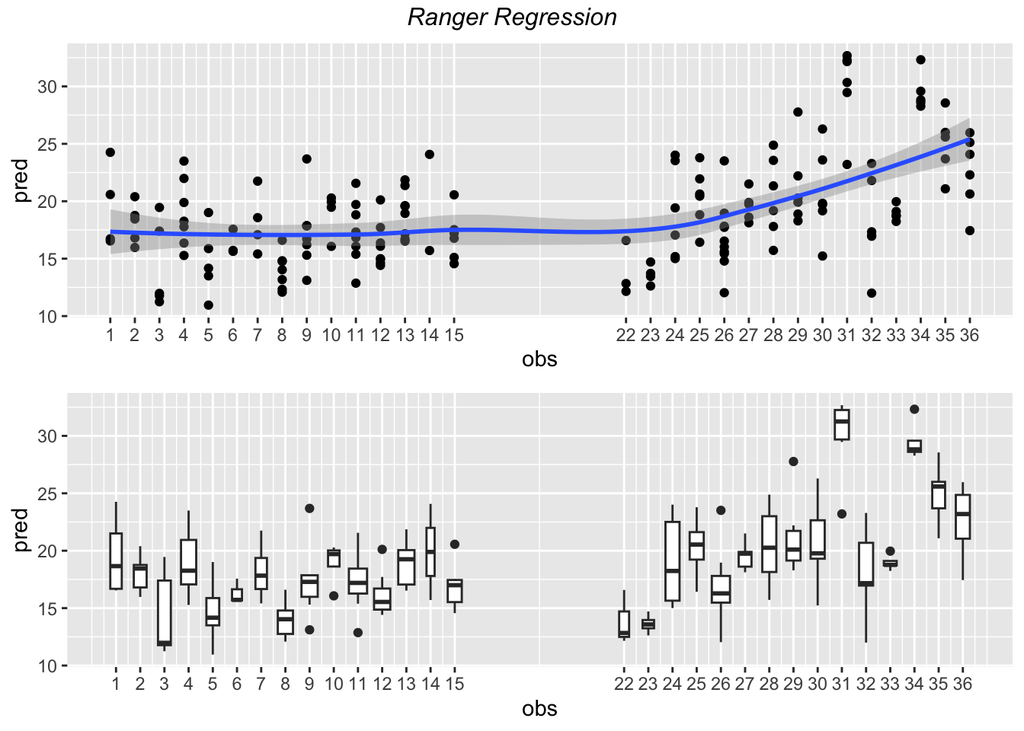

```r
p1 <- ranger_objr$pred |> as.data.frame() |>
    dplyr::select(pred, obs) |>
    ggplot(aes(obs, pred)) +
    geom_point() +
    scale_x_continuous(breaks = c(1:15,22:36)) +
    geom_smooth(method = 'loess', formula = 'y~x')
p2 <- ranger_objr$pred |> as.data.frame() |>
    dplyr::select(pred, obs) |>
    ggplot(aes(obs, pred, group = obs)) +
    geom_boxplot(varwidth = TRUE) +
    scale_x_continuous(breaks = c(1:15,22:36))
grid.arrange(
    p1, p2, nrow = 2,
    top = textGrob(
        "Ranger Regression",
        gp = gpar(fontsize = 12, font = 3)
    )
)
```

## 12.3 Other Metrics

Evidently `ranger` is strong in Specificity (predicting true positives) and relatively weak in Sensitivity (not predicting false positives).

```r
metrics <- c('Sensitivity', 'Specificity', 'Prevalence', 'Precision')
fit     <- ranger(factor(Species) ~ ., train)
pred    <- predict(fit, test)
cm      <- confusionMatrix(pred$predictions, factor(test$Species))
cm$byClass |> as.data.frame() |>
    select(all_of(metrics)) |>
    rownames_to_column(var = 'Species') |>
    mutate(
        Species = names[str_extract(Species, '\\d+')],
        F1 = 2 * ((Precision*Sensitivity)/(Precision+Sensitivity))
    ) |>
    knitr::kable(digits = 3, caption = 'Ranger Classification Metrics') |>
    kable_styling(bootstrap_options = 'bordered')
```

Ranger Classification Metrics

| Species | Sensitivity | Specificity | Prevalence | Precision | F1 |
| --- | --- | --- | --- | --- | --- |
| Quercus suber | 0.625 | 1.000 | 0.047 | 1.000 | 0.769 |
| Salix atrocinerea | 0.600 | 0.988 | 0.030 | 0.600 | 0.600 |
| Populus nigra | 0.600 | 1.000 | 0.030 | 1.000 | 0.750 |
| Alnus sp | 0.000 | 0.994 | 0.006 | 0.000 | NaN |
| Quercus robur | 1.000 | 0.994 | 0.041 | 0.875 | 0.933 |
| Crataegus monogyna | 0.600 | 1.000 | 0.030 | 1.000 | 0.750 |
| Ilex aquifolium | 0.667 | 0.994 | 0.036 | 0.800 | 0.727 |
| Nerium oleander | 1.000 | 0.994 | 0.024 | 0.800 | 0.889 |
| Betula pubescens | 1.000 | 0.957 | 0.036 | 0.462 | 0.632 |
| Tilia tomentosa | 0.667 | 1.000 | 0.053 | 1.000 | 0.800 |
| Acer palmaturu | 1.000 | 0.988 | 0.036 | 0.750 | 0.857 |
| Celtis sp | 0.750 | 0.970 | 0.024 | 0.375 | 0.500 |
| Corylus avellana | 0.800 | 0.982 | 0.030 | 0.571 | 0.667 |
| Castanea sativa | 0.500 | 1.000 | 0.059 | 1.000 | 0.667 |
| Populus alba | 1.000 | 1.000 | 0.024 | 1.000 | 1.000 |
| Primula vulgaris | 0.333 | 0.988 | 0.053 | 0.600 | 0.429 |
| Erodium sp | 0.714 | 1.000 | 0.041 | 1.000 | 0.833 |
| Bougainvillea sp | 0.429 | 0.994 | 0.041 | 0.750 | 0.545 |
| Arisarum vulgare | 1.000 | 1.000 | 0.018 | 1.000 | 1.000 |
| Euonymus japonicus | 0.500 | 0.976 | 0.012 | 0.200 | 0.286 |
| Ilex perado ssp azorica | 0.333 | 1.000 | 0.036 | 1.000 | 0.500 |
| Magnolia soulangeana | 0.500 | 0.982 | 0.036 | 0.500 | 0.500 |
| Buxus sempervirens | 1.000 | 0.969 | 0.036 | 0.545 | 0.706 |
| Urtica dioica | 1.000 | 1.000 | 0.036 | 1.000 | 1.000 |
| Podocarpus sp | 1.000 | 0.988 | 0.030 | 0.714 | 0.833 |
| Acca sellowiana | 0.800 | 0.970 | 0.030 | 0.444 | 0.571 |
| Hydrangea sp | 0.500 | 0.994 | 0.036 | 0.750 | 0.600 |
| Pseudosasa japonica | 0.667 | 1.000 | 0.036 | 1.000 | 0.800 |
| Magnolia grandiflora | 0.667 | 0.975 | 0.036 | 0.500 | 0.571 |
| Geranium sp | 1.000 | 1.000 | 0.024 | 1.000 | 1.000 |

## 12.4 LM Autoplot

From [this write-up](https://www.modernstatisticswithr.com/regression.html), which I’ve referenced in other projects, I’ve paraphrased some potential observations to be made from the plots. Note, these are designed to be plotted together, e.g. `which = 1:6`, but do not render all that well here.

### 12.4.1 Autoplot - “Residuals vs Fitted”

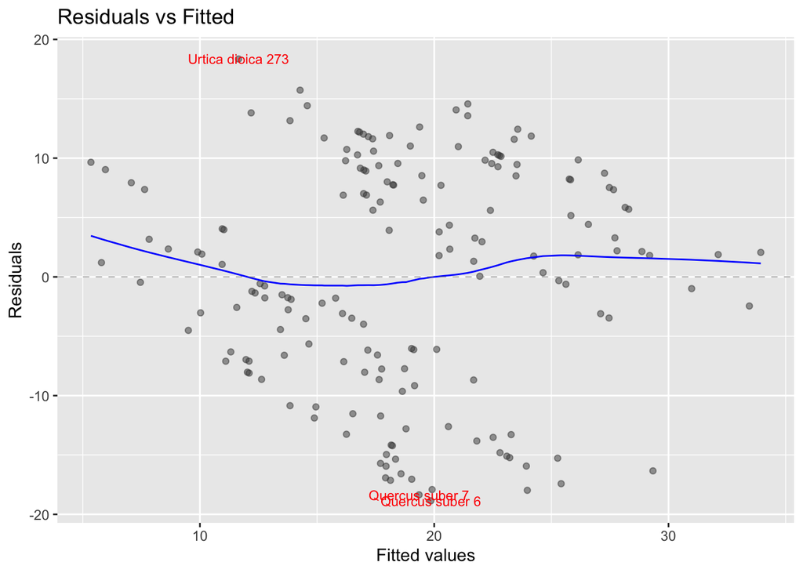

```r
fit  <- lm(Species ~ ., train)
autoplot(fit, which = 1, ncol = 1, label.size = 3, label.colour = 'red', alpha = .5)
```

- *Look for patterns that can indicate non-linearity, e.g. high in some areas and low in others.* **Yes, a high blob and a low blob; thus non-linearity?**
- *Blue line should be close to straight.* **When these were all plotted together, I judged the line to be straight, but not now.**

### 12.4.2 Autoplot - “Normal Q-Q”

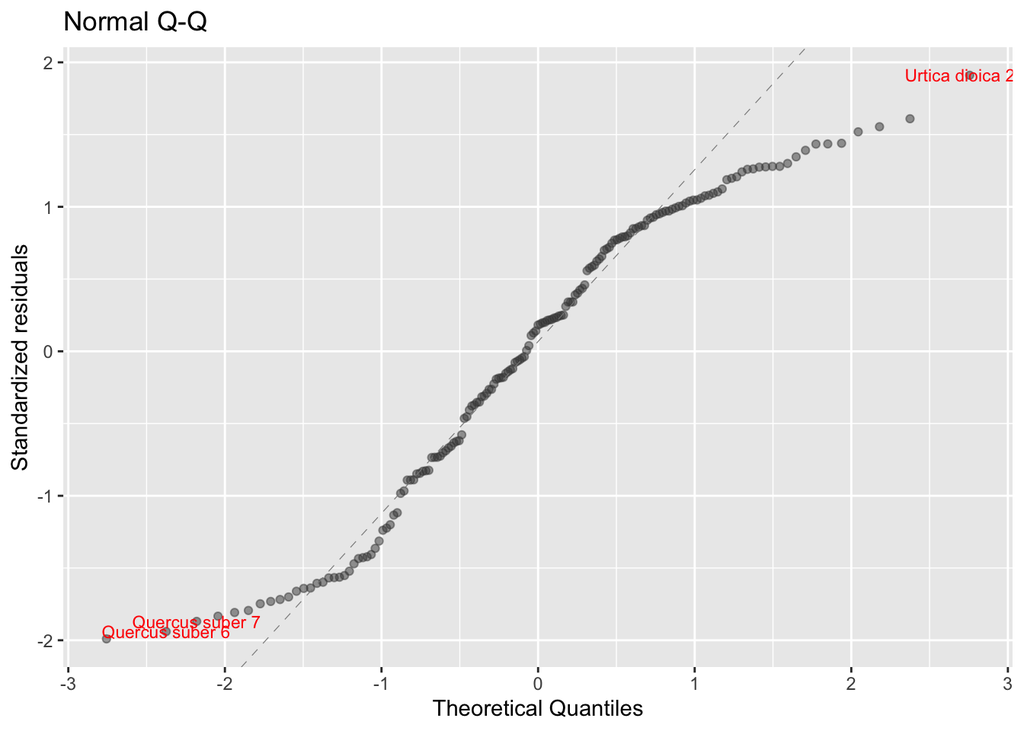

```r
autoplot(fit, which = 2, ncol = 1, label.size = 3, label.colour = 'red', alpha = .5)
```

- *Points follow the line, estimates of random errors follow a normal distribution.* **Again, when all plotted together, the points *seemed* to follow the line quite well. Now, I would say the ends drift away too much.**

### 12.4.3 Autoplot - “Scale-Location”

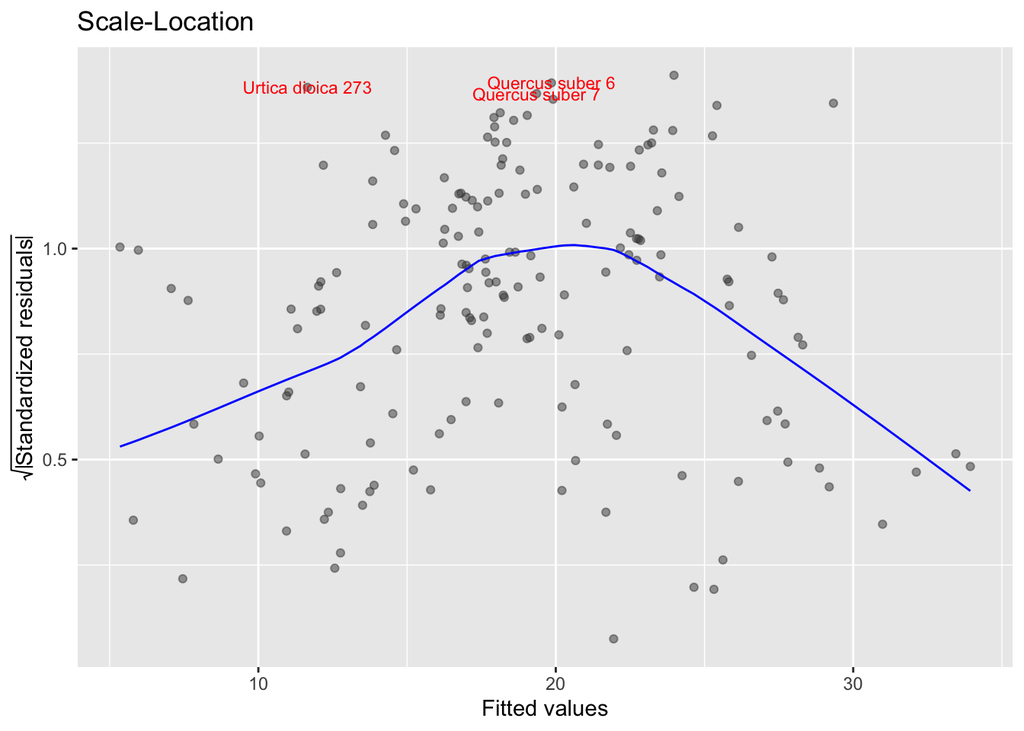

```r
autoplot(fit, which = 3, ncol = 1, label.size = 3, label.colour = 'red', alpha = .5)
```

- *Residuals varying more for large fitted values is a sign of heteroscedasticity.* **Residuals vary all along, and mostly near the middle.**
- *Horizontal blue line is a sign of homoscedasticity (both defined [here](https://en.wikipedia.org/wiki/Homoscedasticity_and_heteroscedasticity)).* **Not horizontal; and coupled with the above, I reckon this is heteroscedasticity.**

### 12.4.4 Autoplot - “Cook’s Distance”

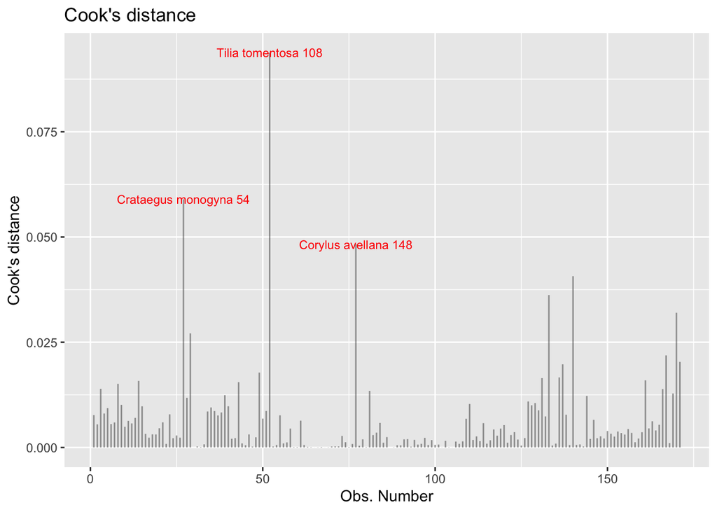

```r
autoplot(fit, which = 4, ncol = 1, label.size = 3, label.colour = 'red', alpha = .5)
```

- *Points with high values (rule of thumb, above 1) indicate high influence.* **Nothing close to 1, but there are certainly some outliers.**

### 12.4.5 Autoplot - “Residuals vs Leverage”

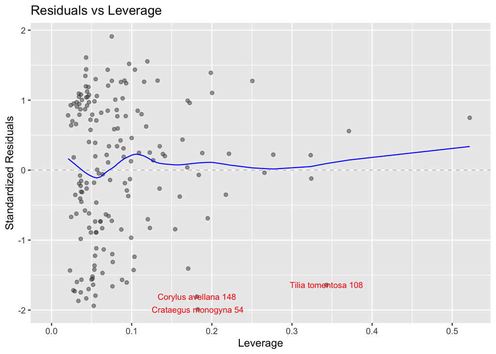

```r
autoplot(fit, which = 5, ncol = 1, label.size = 3, label.colour = 'red', alpha = .5)
```

- *High residual, low leverage indicates deviation from the model with little influence.* **Assuming “high” is above the faint dashed line, yes there is a clump with high residual and low(?) leverage.**
- *High residual, high leverage indicates strong influence on the fitted model.* **No, I would say everything with high leverage has moderate to low residuals.**

### 12.4.6 Autoplot - “Cook’s Distance vs Leverage”

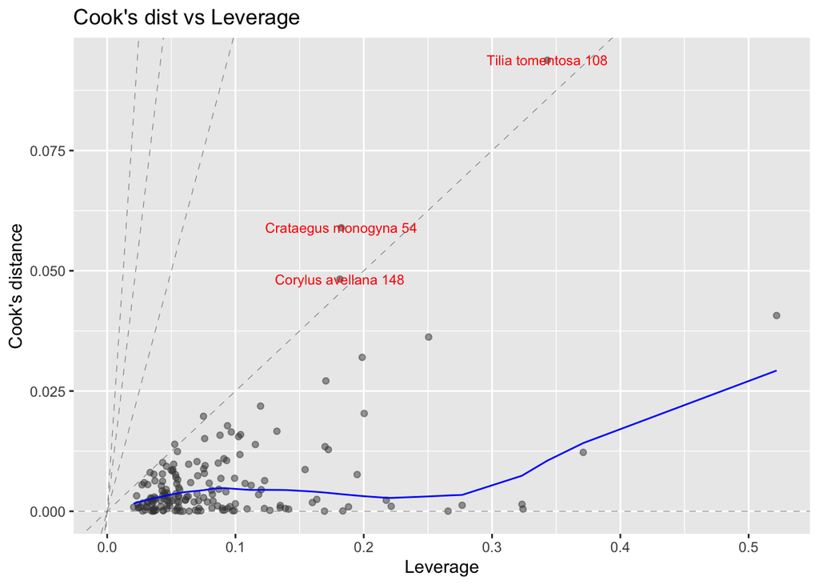

```r
autoplot(fit, which = 6, ncol = 1, label.size = 3, label.colour = 'red', alpha = .5)
```

### 12.4.7 Autoplot - All Together, Without Outliers

For no reason I can explain, even with `set.seed`, the specifics vary in these plots every run. But, over many runs, there is definite repetition - usually Tilia tomentosa, Geranium sp, and Quercus suber, and less often Corylus avellana, Crataegus monogyna, Nerium oleander, and Urtica dioica.

Below are many of the rows that have been repeatedly highlighted. While some of the column values *look* very large or small, they are not when compared to the `max` or `min` values of the same columns. (For the record, I am familiar with Tilia (Linden) and its fragrant flowers.)

```r
recurring_outliers <- c(
    'Quercus suber 6', 'Quercus suber 7', 'Quercus suber 9', 'Quercus suber 10',
    'Geranium sp 331', 'Geranium sp 340',
    'Tilia tomentosa 97', 'Tilia tomentosa 108',
    'Crataegus monogyna 54', 'Corylus avellana 148'
)
data <- train |> filter(row.names(train) %in% recurring_outliers) |>
    rownames_to_column(var = 'GenusSpecimen') |>
    mutate(GenusSpecimen = sub(' [a-z]+ ', ' ... ', GenusSpecimen)) |>
    select(-c(Species))

knitr::kable(data, digits = 2, align = 'c', caption = 'Recurring Autoplot Outliers') |>
    kable_styling(bootstrap_options = 'bordered') |>
    row_spec(
        0,
        angle = -60,
        extra_css = 'line-height: 100px; column-width: 2px; opacity: .5'
    ) |>
    column_spec(1, bold = TRUE, extra_css = 'text-align: left') |>
    column_spec(2:ncol(data), border_left = TRUE)
```

Recurring Autoplot Outliers

| GenusSpecimen | Eccentricity | AspectRatio | Elongation | Solidity | StochasticConvexity | IsoperimetricFactor | MaxIndentationDepth | Lobedness | AverageIntensity | AverageContrast | Smoothness | ThirdMoment | Uniformity | Entropy |
| --- | --- | --- | --- | --- | --- | --- | --- | --- | --- | --- | --- | --- | --- | --- |
| Quercus … 6 | 0.73 | 1.49 | 0.34 | 0.99 | 1.00 | 0.84 | 0.00 | 0.00 | 0.01 | 0.06 | 0.00 | 0.00 | 0 | 0.34 |
| Quercus … 7 | 0.82 | 1.75 | 0.44 | 0.98 | 1.00 | 0.77 | 0.01 | 0.01 | 0.02 | 0.08 | 0.01 | 0.00 | 0 | 0.54 |
| Crataegus … 54 | 0.51 | 1.05 | 0.62 | 0.74 | 0.60 | 0.28 | 0.13 | 3.22 | 0.01 | 0.07 | 0.00 | 0.00 | 0 | 0.52 |
| Tilia … 108 | 0.36 | 1.06 | 0.26 | 0.94 | 0.97 | 0.59 | 0.05 | 0.45 | 0.19 | 0.28 | 0.07 | 0.02 | 0 | 2.66 |
| Corylus … 148 | 0.67 | 1.40 | 0.31 | 0.98 | 1.00 | 0.80 | 0.01 | 0.01 | 0.12 | 0.18 | 0.03 | 0.01 | 0 | 2.51 |
| Geranium … 331 | 0.39 | 1.10 | 0.73 | 0.72 | 0.69 | 0.18 | 0.08 | 1.05 | 0.06 | 0.16 | 0.02 | 0.01 | 0 | 1.20 |
| Geranium … 340 | 0.47 | 1.09 | 0.85 | 0.54 | 0.40 | 0.08 | 0.13 | 3.18 | 0.08 | 0.19 | 0.03 | 0.01 | 0 | 1.56 |

Below I filter out those rows and re-plot. Again, these are difficult to see all together. I hoped to plot the originals and these side-by-side with `gridExtra` or `cowplot`, but it is not that straightforward if even possible. I did plot these individually and eyeballed against the originals and there seems to be an overall effect/improvement: generally points shifted slightly down and leftward. Most notably, the y-axis scales shrank for the two Cook’s plots.

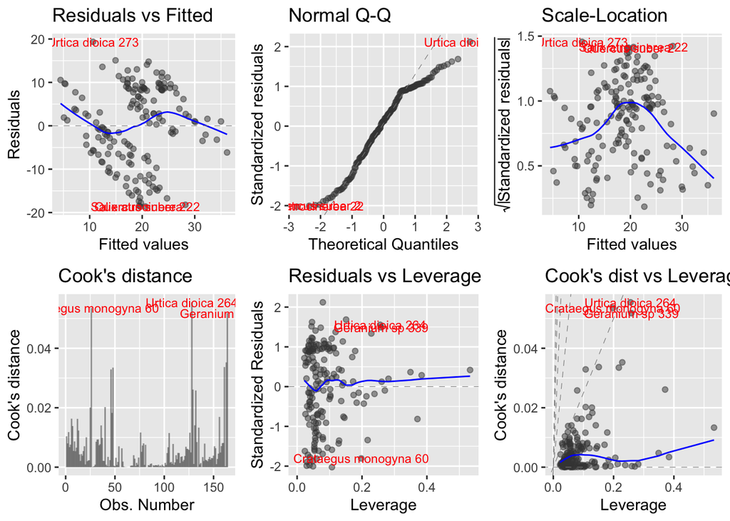

```r
fit <- lm(Species ~ ., train |> filter(!row.names(train) %in% recurring_outliers))
autoplot(fit, which = 1:6, ncol = 3, label.size = 3, label.colour = 'red', alpha = .5)
```

### 12.4.8 Removing Recurring Autoplot Outliers

```r
tmp <- train |> filter(!row.names(train) %in% recurring_outliers)

model_results <- model_results |> add_row(
    tibble_row(
        Model    = 'w/o autoplot outliers',
        RMSE     = lm__(tmp, test),
        Accuracy = NULL
    ),
    .after = rows_per()
)
model_results <- model_results |> add_row(
    tibble_row(
        Model    = 'w/o autoplot outliers',
        RMSE     = ranger__r(tmp, test),
        Accuracy = ranger__c(tmp, test)
    ),
    .after = 2 * rows_per() + 1
)
model_results <- model_results |> add_row(
    tibble_row(
        Model    = 'w/o autoplot outliers',
        RMSE     = rf__r(tmp, test),
        Accuracy = rf__c(tmp, test)
    )
)
```

Minimal and mixed results.

```r
model_summary()
```

| Model | Regression RMSE | Classification Accuracy |
| --- | --- | --- |
| **lm** |  |  |
| baseline | 10.212 | NA |
| centering | 10.135 | NA |
| <90% correlation | 10.110 | NA |
| minus top 3 VIF | 10.142 | NA |
| train() | 10.430 | NA |
| w/o autoplot outliers | 10.438 | NA |
| **ranger** |  |  |
| baseline | 8.054 | 71.006 |
| centering | 8.166 | 71.006 |
| <90% correlation | 7.851 | 70.414 |
| minus top 3 VIF | 7.915 | 69.231 |
| train() | 8.355 | 60.947 |
| w/o autoplot outliers | 8.625 | 65.680 |
| **randomForest** |  |  |
| baseline | 8.066 | 69.231 |
| centering | 8.346 | 66.272 |
| <90% correlation | 8.515 | 66.864 |
| minus top 3 VIF | 8.205 | 66.272 |
| train() | 8.565 | 60.355 |
| w/o autoplot outliers | 8.290 | 63.905 |

# 13 RowSDs and ColSDs

Here I plot `rowSDs` vs Species - and there are two or three pronounced genuses - 34 (*Pseudosasa japonica*), 31 (*Podocarpus sp*), and to a lesser extend, 8 (*Nerium oleander*).

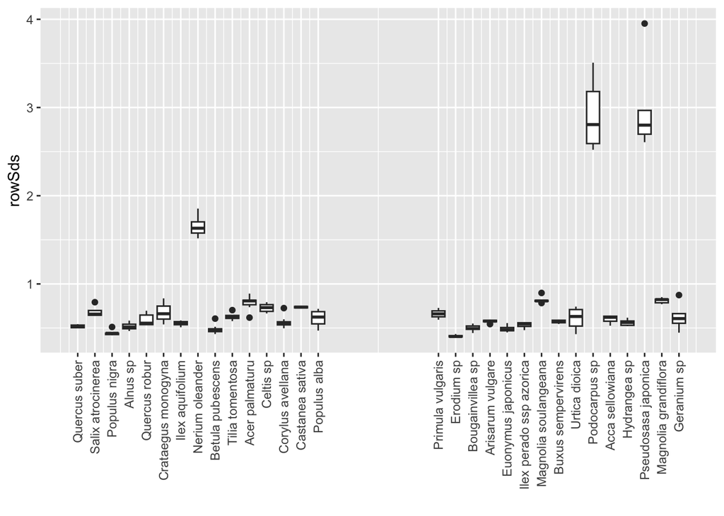

```r
x  <- train$Species
y  <- rowSds(train[,2:15] |> as.matrix())   # visibly same with rowSums
ggplot() +
    geom_boxplot(aes(x, y, group = x)) +
    scale_x_continuous(
        breaks = c(1:15,22:36),
        labels = as.vector(names)
    ) +
    theme(axis.text.x = element_text(angle = 90, vjust = .5, hjust = 1)) +
    labs(x = '', y = 'rowSds')
```

Anything to glean from columns?

```r
colSds(train[,2:15] |>
    as.matrix()) |>
    as.data.frame() |>
    rownames_to_column(var = 'Column') |>
    mutate(colSd = cur_data_all()[[2]]) |>
    select(-c(2)) |>
    arrange(desc(colSd)) |>
    knitr::kable() |>
    kable_styling(bootstrap_options = c('bordered', 'striped', 'condensed'))
```

| Column | colSd |
| --- | --- |
| AspectRatio | 2.5449173 |
| Lobedness | 1.0713722 |
| Entropy | 0.5865148 |
| IsoperimetricFactor | 0.2258662 |
| Eccentricity | 0.2047231 |
| Elongation | 0.2027988 |
| Solidity | 0.1219441 |
| StochasticConvexity | 0.1188281 |
| AverageContrast | 0.0511618 |
| MaxIndentationDepth | 0.0386710 |
| AverageIntensity | 0.0363404 |
| Smoothness | 0.0138999 |
| ThirdMoment | 0.0053201 |
| Uniformity | 0.0004134 |

Intuitively, and cross-referencing with the RandomForest decision tree, it seems plausible that the columns with very low standard deviations are not useful predictors. Perhaps `colSDs` for continuous data can be considered analogous to `nearZeroVar` for discrete data. That seems consistent with RMSE (proximity) vs. Accuracy (binary, right or wrong).

I’ll try the models again after removing columns with SDs below 0.1.

```r
low_sds <- colSds(train[,2:15] |>
    as.matrix()) |>
    as.data.frame() |>
    rownames_to_column(var = 'Column') |>
    mutate(colSd = cur_data_all()[[2]]) |>
    filter(colSd < 0.1) |>
    pull(Column)
tmp <- train |> select(-c(all_of(low_sds)))

model_results <- model_results |> add_row(
    tibble_row(
        Model    = '<0.1 SD',
        RMSE     = lm__(tmp, test),
        Accuracy = NULL
    ),
    .after = rows_per()
)
model_results <- model_results |> add_row(
    tibble_row(
        Model    = '<0.1 SD',
        RMSE     = ranger__r(tmp, test),
        Accuracy = ranger__c(tmp, test)
    ),
    .after = 2 * rows_per() + 1
)
model_results <- model_results |> add_row(
    tibble_row(
        Model    = '<0.1 SD',
        RMSE     = rf__r(tmp, test),
        Accuracy = rf__c(tmp, test)
    )
)
```

Again, mixed and minimal results.

```r
model_summary()
```

| Model | Regression RMSE | Classification Accuracy |
| --- | --- | --- |
| **lm** |  |  |
| baseline | 10.212 | NA |
| centering | 10.135 | NA |
| <90% correlation | 10.110 | NA |
| minus top 3 VIF | 10.142 | NA |
| train() | 10.430 | NA |
| w/o autoplot outliers | 10.438 | NA |
| <0.1 SD | 10.354 | NA |
| **ranger** |  |  |
| baseline | 8.054 | 71.006 |
| centering | 8.166 | 71.006 |
| <90% correlation | 7.851 | 70.414 |
| minus top 3 VIF | 7.915 | 69.231 |
| train() | 8.355 | 60.947 |
| w/o autoplot outliers | 8.625 | 65.680 |
| <0.1 SD | 8.496 | 64.497 |
| **randomForest** |  |  |
| baseline | 8.066 | 69.231 |
| centering | 8.346 | 66.272 |
| <90% correlation | 8.515 | 66.864 |
| minus top 3 VIF | 8.205 | 66.272 |
| train() | 8.565 | 60.355 |
| w/o autoplot outliers | 8.290 | 63.905 |
| <0.1 SD | 8.939 | 63.314 |

# 14 Formula Modifications

To date, I’ve only experimented rather blindly with formulas. At this point, `train` has three pairs with absolute correlation at or above .75: IsoperimetricFactor/Solidity (0.75), Lobedness/Solidity (-0.81), and Elongation/IsoperimetricFactor (-0.80). Here I try factor-crossing those pairs.

```r
fc <- as.formula(
    factor(Species) ~ IsoperimetricFactor*Solidity
            + Lobedness*Solidity
            + Elongation*IsoperimetricFactor
            + .
)
fr <- as.formula(
    Species ~ IsoperimetricFactor*Solidity
            + Lobedness*Solidity
            + Elongation*IsoperimetricFactor
            + .
)
model_results <- model_results |> add_row(
    tibble_row(
        Model    = 'factor crossing',
        RMSE     = lm__(train, test, formula = fr),
        Accuracy = NULL
    ),
    .after = rows_per()
)
model_results <- model_results |> add_row(
    tibble_row(
        Model    = 'factor crossing',
        RMSE     = NULL, # One or more independent variables not found
        Accuracy = NULL  # ditto
    ),
    .after = 2 * rows_per() + 1
)
model_results <- model_results |> add_row(
    tibble_row(
        Model    = 'factor crossing',
        RMSE     = rf__r(train, test, formula = fr),
        Accuracy = rf__c(train, test, formula = fc)
    )
)
```

Noted in the code above, `ranger` gives an error. For the other two, mixed and minimal results.

```r
model_summary()
```

| Model | Regression RMSE | Classification Accuracy |
| --- | --- | --- |
| **lm** |  |  |
| baseline | 10.212 | NA |
| centering | 10.135 | NA |
| <90% correlation | 10.110 | NA |
| minus top 3 VIF | 10.142 | NA |
| train() | 10.430 | NA |
| w/o autoplot outliers | 10.438 | NA |
| <0.1 SD | 10.354 | NA |
| factor crossing | 9.944 | NA |
| **ranger** |  |  |
| baseline | 8.054 | 71.006 |
| centering | 8.166 | 71.006 |
| <90% correlation | 7.851 | 70.414 |
| minus top 3 VIF | 7.915 | 69.231 |
| train() | 8.355 | 60.947 |
| w/o autoplot outliers | 8.625 | 65.680 |
| <0.1 SD | 8.496 | 64.497 |
| factor crossing | NA | NA |
| **randomForest** |  |  |
| baseline | 8.066 | 69.231 |
| centering | 8.346 | 66.272 |
| <90% correlation | 8.515 | 66.864 |
| minus top 3 VIF | 8.205 | 66.272 |
| train() | 8.565 | 60.355 |
| w/o autoplot outliers | 8.290 | 63.905 |
| <0.1 SD | 8.939 | 63.314 |
| factor crossing | 8.040 | 63.314 |

# 15 Other Models

Here I just try other models I’ve experimented with in the past, hoping one will be a standout fit for this data. This is the first use case I’ve had for `mapply`, to pass TWO lists to a function. Straightforward, though I had to change `tuning` from `c()` to `list()`.

### 15.0.1 Other Regression Models - glm, knn, rlm

```r
models <- c('glm', 'knn', 'rlm')
tuning <- list(
    glm = data.frame(parameter = 'none'),
    knn = data.frame(k=seq(1,10,.5)),
    rlm = expand.grid(
        intercept = c(TRUE, FALSE),
        psi       = c('psi.huber', 'psi.hampel', 'psi.bisquare')
    )
)

mapply(function(model, tune) {
    fit <- train(
          Species ~ .,
          method     = model,
          data       = train,
          trControl  = trControl,
          tuneGrid   = tune,
          preProcess = c('pca', 'corr')
    )
    rmse = rmse(fit, test)
    c(model = rmse)
}, models, tuning[c(models)])
```

```
## glm.model knn.model rlm.model
##    10.430     9.084    10.430
```

`knn` is a regression contender.

### 15.0.2 Other Classification Models - multinom, Rborist, mlp, wsrf

```r
models <- c('multinom', 'Rborist', 'mlp', 'wsrf')
tuning <- list(
    multinom = data.frame(decay = c(.01, .1, .5, .75)),
    Rborist  = expand.grid(
        predFixed = c(2,20),
        minNode   = c(2,5,10)
    ),
    mlp      = data.frame(size = c(1,5,10)),
    wsrf     = data.frame(mtry = c(1,2,5,10))
)

mapply(function(model, tune) {
    fit <- train(
          factor(Species) ~ .,
          method     = model,
          data       = train,
          trControl  = trControl,
          tuneGrid   = tune,
          preProcess = c('pca', 'corr'),
          trace      = FALSE
    )
    accuracy <- accuracy(fit, test)
    c(model = accuracy)
}, models, tuning[c(models)])
```

```
## multinom.model  Rborist.model      mlp.model     wsrf.model
##         68.639         62.130         42.012         57.988
```

`multinom` is a classification contender.

# 16 Final Four

Here I take another look at the top two classification models, `multinom` and `ranger`, and top two regression models, `knn` and `randomForest`.

```r
models  <- c('multinom', 'ranger', 'knn', 'rf')
```

What other dials can I turn?

## 16.1 tuneGrid Parameters

Here I establish a list of `tuneGrid` objects for the four models.

```r
tuning  <- list(
    multinom = data.frame(decay = seq(.0020,.0040,.0002)),
    ranger   = expand.grid(
          mtry          = c(1,2,3),
          splitrule     = c('gini', 'extratrees'),
          min.node.size = seq(1,5,1)
    ),
    knn      = data.frame(k = seq(1,10,.5)),
    rf       = data.frame(mtry = seq(1,5,.1))
)
```

## 16.2 preProcess Methods

And here, a list of experimental `preProcess` vectors for the models.

```r
preprocesses <- list(
    multinom = c('pca'),
    ranger   = c('pca', 'BoxCox'),
    knn      = c('pca', 'corr', 'expoTrans'),
    rf       = c('pca', 'YeoJohnson')
)
```

## 16.3 Formula Variations

Here I define three pairs of formulas, for classification and regression.

```r
formulas <- list(
    c1 = as.formula(factor(Species) ~ .),
    r1 = as.formula(Species ~ .),
    c2 = as.formula(
        factor(Species) ~ IsoperimetricFactor * Solidity
            + Lobedness * Solidity
            + Elongation * IsoperimetricFactor
            + .
    ),
    r2 = as.formula(
        Species ~ IsoperimetricFactor * Solidity
            + Lobedness * Solidity
            + Elongation * IsoperimetricFactor
            + .
    ),
    c3 = as.formula(
        factor(Species) ~ IsoperimetricFactor * Solidity
            + Lobedness * Solidity
            + Elongation * IsoperimetricFactor
            + I(Eccentricity^3)
            + .
    ),
    r3 = as.formula(
        Species ~ IsoperimetricFactor * Solidity
            + Lobedness * Solidity
            + Elongation * IsoperimetricFactor
            + I(Eccentricity^3)
            + .
    )
)
```

## 16.4 Execute with mapply

Here I use `mapply` and an anonymous function to do most of the work, wrapped with an outer function to make the arguments flexible.

```r
execute_models <- function(
    .train        = train,
    .test         = test,
    .formulas     = formulas[c('c2', 'c2', 'r2', 'r2')],
    .tuning       = tuning[c(models)],
    .preprocesses = preprocesses[c(models)]
) {
    results <- vector()
    results <- mapply(function(model, tune, formula, pre) {
        fit <- train(
              formula,
              method        = model,
              data          = .train,
              trControl     = trControl,
              tuneGrid      = tune,
              preProcess    = pre,
              trace         = FALSE,
              cutoff        = .9,  # correlation cutoff, default 90%
              thresh        = .8,  # PCA threshold, default 95%
              na.action     = na.pass
        )
        if (fit$modelType == 'Regression') {
            metric <- rmse(fit, .test)
        }
        else {
            metric <- accuracy(fit, .test)
        }
        results <- append(results, metric)
    },
        models,
        .tuning,
        .formulas,
        .preprocesses
    )
    return(bind_rows(results))
}
```

Now execute the models with various arguments.

```r
metrics <- execute_models()
metrics <- rbind(metrics, execute_models(
    train |> select(-c(all_of(low_sds)))
))
metrics <- rbind(metrics, execute_models(
    train |> filter(!row.names(train) %in% recurring_outliers)
))
metrics <- rbind(metrics, execute_models(
    train |> select(-c(all_of(high_corr)))
))
metrics <- rbind(metrics, execute_models(
    .train    = train |> select(-c(all_of(high_corr))),
    .formulas = formulas[c('c1','c1','r1','r1')]
))
metrics <- rbind(metrics, execute_models(
    .train     = train |> select(-c(all_of(high_vif))),
    .formulas = formulas[c('c1','c1','r1','r1')]
))
metrics <- rbind(metrics, execute_models(
    .train    = train |> select(-c(all_of(high_vif))),
    .formulas = formulas[c('c3','c1','r3','r3')]
))
metrics <- rbind(metrics, execute_models(
    .train    = train,
    .formulas = formulas[c('c3','c1','r3','r3')]
))
metrics <- rbind(metrics, execute_models(
    train |> mutate(across(-c(Species), ~ scale(.x, center=TRUE, scale=FALSE))),
    test  |> mutate(across(-c(Species), ~ scale(.x, center=TRUE, scale=FALSE)))
))
metrics <- rbind(metrics, execute_models(
    train |> mutate(across(-c(Species), ~ scale(.x, center=TRUE, scale=TRUE))),
    test  |> mutate(across(-c(Species), ~ scale(.x, center=TRUE, scale=TRUE)))
))
metrics <- rbind(metrics, execute_models(
    train |> select(-c(all_of(high_corr))) |>
             mutate(across(-c(Species), ~ scale(.x, center=TRUE, scale=FALSE))),
    test  |> mutate(across(-c(Species), ~ scale(.x, center=TRUE, scale=FALSE)))
))
metrics <- rbind(metrics, execute_models(
    .train    = train_x,
    .formulas = formulas[c('c1','c1','r1','r1')],
    .pre      = list(
        multinom = c('pca', 'corr', 'medianImpute'),
        ranger   = c('pca', 'corr', 'medianImpute'),
        knn      = c('pca', 'corr', 'medianImpute'),
        rf       = c('pca', 'corr', 'medianImpute')
    )
))
metrics <- rbind(metrics, execute_models(
    .train    = train_x,
    .formulas = formulas[c('c1','c1','r1','r1')],
    .pre      = list(
        multinom = c('pca', 'corr', 'bagImpute'),
        ranger   = c('pca', 'corr', 'bagImpute'),
        knn      = c('pca', 'corr', 'bagImpute'),
        rf       = c('pca', 'corr', 'bagImpute')
    )
))
metrics <- rbind(metrics, execute_models(
    .train    = train_o,
    .formulas = formulas[c('c1','c1','r1','r1')],
    .pre      = list(
        multinom = c('pca', 'corr', 'medianImpute'),
        ranger   = c('pca', 'corr', 'medianImpute'),
        knn      = c('pca', 'corr', 'medianImpute'),
        rf       = c('pca', 'corr', 'medianImpute')
    )
))
metrics <- rbind(metrics, execute_models(
    .train    = train_o,
    .formulas = formulas[c('c1','c1','r1','r1')],
    .pre      = list(
        multinom = c('pca', 'corr', 'bagImpute'),
        ranger   = c('pca', 'corr', 'bagImpute'),
        knn      = c('pca', 'corr', 'bagImpute'),
        rf       = c('pca', 'corr', 'bagImpute')
    )
))
```

And the results:

```r
metrics |> add_column(
    summary = c(
        'basic', 'omit low SDs', 'omit recurring outliers',
        'omit high correlation', 'omit high correlation, v1 formula',
        'omit high VIF, v1 formula', 'omit high VIF, v3 formula',
        'v3 formula', 'centered', 'centered and scaled',
        'omit high correlation, centered',
        'medianImpute extremes', 'bagImpute extremes',
        'medianImpute outliers/extremes', 'bagImpute outliers/extremes'
    ),
    .before = 1
) |> knitr::kable() |> kable_styling(bootstrap_options = 'bordered')
```

| summary | multinom | ranger | knn | rf |
| --- | --- | --- | --- | --- |
| basic | 68.639 | 60.947 | 8.898 | 9.083 |
| omit low SDs | 63.314 | 60.355 | 8.689 | 9.276 |
| omit recurring outliers | 69.231 | 62.722 | 9.450 | 9.287 |
| omit high correlation | 66.272 | 62.130 | 8.775 | 8.760 |
| omit high correlation, v1 formula | 71.006 | 54.438 | 8.966 | 8.532 |
| omit high VIF, v1 formula | 69.822 | 56.213 | 9.466 | 8.797 |
| omit high VIF, v3 formula | 69.822 | 56.805 | 9.144 | 8.449 |
| v3 formula | 69.231 | 57.988 | 8.822 | 9.064 |
| centered | 66.272 | 63.314 | 9.184 | 8.759 |
| centered and scaled | 66.272 | 60.355 | 9.277 | 8.726 |
| omit high correlation, centered | 67.456 | 60.947 | 9.082 | 8.734 |
| medianImpute extremes | 62.722 | 56.805 | 9.141 | 8.684 |
| bagImpute extremes | 65.089 | 60.947 | 9.325 | 8.639 |
| medianImpute outliers/extremes | 62.722 | 54.438 | 9.141 | 8.657 |
| bagImpute outliers/extremes | 64.497 | 62.722 | 9.026 | 8.830 |

Note, `knnImpute` gave “Something is wrong; all the Accuracy metric values are missing”. I looked into it lightly, especially [here](https://stackoverflow.com/questions/52303475/error-using-caret-package-with-knn-method-something-is-wrong-all-the-accur) - and tried adding `'center', 'scale'` to the mix and increased `k` from default 5 to to 10, to no avail.

More notably, `'medianImpute'` and `'bagImpute'` failed also until I added `'na.action = na.pass'`. That almost feels like a bug, or at least a missed feature - that NAs should be allowed if one is trying to impute [them]. I will be poking around github for the source code and look to make a patch.

# 17 Final One - multinom

Here I focus on `multinom`, which generally looks best. Notably, `multinom` supports case weights, to help control how observations effect the model. I experiment with weights here, and also with `rowSds` and `colSds` as a proxy for volatility.

```r
row_sds    <- rowSds(train[,2:15] |> as.matrix())
col_sds    <- colSds(train[,2:15] |> as.matrix())
f_weights  <- train |> group_by(Species) |> mutate(n = n()) |> pull(n)
p_weights  <- parsnip::importance_weights(row_sds) |> as.double()
sd_weights <- row_sds
row_sds    <- row_sds |> as.data.table(keep.rownames = TRUE)
col_sds    <- col_sds |> as.data.table(keep.rownames = TRUE)

most_volatile_rows <- row_sds |>
    slice_max(order_by = row_sds, n = 5) |> pull(rn)

least_volatile_rows <- row_sds |>
    slice_min(order_by = row_sds, n = 5) |>  pull(rn)

most_volatile_columns <- col_sds |>
    slice_max(order_by = col_sds, n = 5) |>  pull(rn)

least_volatile_columns <- col_sds |>
    slice_min(order_by = col_sds, n = 5) |>  pull(rn)
```

## 17.1 Multinom via Train

I tried to construct permutations of formulas, `tuneGrid`, and `preProcess` with `expand.grid` - and it looked fine to me as a data frame but something about it wasn’t playing well with `train`.

```r
execute_multinom <- function(
        .formula = formulas[['c1']],
        .tune    = data.frame(decay = .0033),
        .pre     = c('pca', 'corr'),
        .train   = train,
        .test    = test,
        .weights = vector()
    ) {
    fit <- train(
          .formula,
          method       = 'multinom',
          data         = .train,
          trControl    = trControl,
          tuneGrid     = .tune,
          preProcess   = .pre,
          trace        = FALSE,
          case.weights = .weights
    )
    return(accuracy(fit, .test))
}
```

Now to run with various arguments.

```r
metrics <- vector()
metrics <- append(metrics, c(
    execute_multinom(),
    execute_multinom(.weights = f_weights),
    execute_multinom(.weights = p_weights),
    execute_multinom(.formula = formulas[['c2']]),
    execute_multinom(.formula = formulas[['c3']]),
    execute_multinom(
        .train = train|> select(-c(all_of(high_corr)))
    ),
    execute_multinom(.pre = c('pca', 'corr', 'scale', 'center')),
    execute_multinom(.pre = c('pca', 'corr', 'BoxCox')),
    execute_multinom(.pre = c('pca', 'corr', 'YeoJohnson')),
    execute_multinom(.pre = c('pca', 'corr', 'expoTrans')),
    execute_multinom(
        .train = train |> filter(!rownames(train) %in% c(most_volatile_rows))
    ),
    execute_multinom(
        .train = train |> filter(!rownames(train) %in% c(least_volatile_rows))
    ),
    execute_multinom(
        .train = train |> select(-c(all_of(most_volatile_columns)))
    ),
    execute_multinom(
        .train = train |> select(-c(all_of(least_volatile_columns)))
    ),
    execute_multinom(
        .train = impute_mean(train_o)
    ),
    execute_multinom(
        .train = impute_mean(train_x)
    ),
    execute_multinom(
        .train = impute_median(train_o)
    ),
    execute_multinom(
        .train = impute_median(train_o)
    ),
    execute_multinom(
        .formula = formulas[['c3']],
        .train   = impute_mean(train_x)
    )
))
```

And the results:

```r
cbind(c(
        'new baseline',
        'new baseline; plus frequency weights',
        'new baseline; plus precision weights',
        'new baseline; but formula v2',
        'new baseline; but formula v3',
        'new baseline; omit high-corr',
        'new baseline; plus center/scale',
        'new baseline; plus BoxCox',
        'new baseline; plus YeoJohnson',
        'new baseline; plus expoTrans',
        'new baseline; omit most volatile rows',
        'new baseline; omit least volatile rows',
        'new baseline; omit most volatile cols',
        'new baseline; omit least volatile cols',
        'new baseline; mean-impute outliers',
        'new baseline; mean-impute outliers and extremes',
        'new baseline; median-impute outliers',
        'new baseline; median-impute outliers and extremes',
        'new baseline; mean-impute outliers and extremes, formula v3'
    ),
    metrics
) |> knitr::kable(col.names = c('Model', 'Accuracy'), caption = 'Multinom via Train') |>
     kable_styling(bootstrap_options = 'bordered') |> footnote(
         general = 'new baseline definition:',
         number  = c(
             'formula:  `factor(Species) ~ .`',
             'preProcess: `c("pca", "corr")`',
             'tuneGrid: `data.frame(decay = .0033)`'
         )
     )
```

Multinom via Train

| Model | Accuracy |
| --- | --- |
| new baseline | 69.822 |
| new baseline; plus frequency weights | 69.822 |
| new baseline; plus precision weights | 69.822 |
| new baseline; but formula v2 | 68.639 |
| new baseline; but formula v3 | 65.089 |
| new baseline; omit high-corr | 71.006 |
| new baseline; plus center/scale | 69.822 |
| new baseline; plus BoxCox | 58.58 |
| new baseline; plus YeoJohnson | 69.822 |
| new baseline; plus expoTrans | 66.864 |
| new baseline; omit most volatile rows | 66.272 |
| new baseline; omit least volatile rows | 68.047 |
| new baseline; omit most volatile cols | 60.947 |
| new baseline; omit least volatile cols | 63.314 |
| new baseline; mean-impute outliers | 61.538 |
| new baseline; mean-impute outliers and extremes | 61.538 |
| new baseline; median-impute outliers | 61.538 |
| new baseline; median-impute outliers and extremes | 61.538 |
| new baseline; mean-impute outliers and extremes, formula v3 | 62.722 |

Note:  
new baseline definition:  
<sup>1</sup> formula: `factor(Species) ~ .`  
<sup>2</sup> preProcess: `c("pca", "corr")`  
<sup>3</sup> tuneGrid: `data.frame(decay = .0033)`

## 17.2 Multinom via NNET

Here I look to run `multinom` directly.

```r
f1 <- formulas[['c1']]; f2 <- formulas[['c2']]; f3 <- formulas[['c3']]
metrics <- vector()
metrics <- append(metrics, c(
    accuracy(
        multinom(f1, train, trace = FALSE, decay = .00015), test
    ),
    accuracy(
        multinom(f1, train, trace = FALSE, decay = .00015, weights = f_weights),
        test
    ),
    accuracy(
        multinom(f1, train, trace = FALSE, decay = .00015, weights = p_weights),
        test
    ),
    accuracy(
        multinom(f1, train, trace = FALSE, decay = .00015, weights = 1/p_weights),
        test
    ),
    accuracy(
        multinom(f1, train, trace = FALSE, decay = .00015, weights = sd_weights),
        test
    ),
    accuracy(
        multinom(f1, train, trace = FALSE, decay = .00015,
            subset = sample(1:nrow(train), round(nrow(train)/2))
        ), test
    ),
    accuracy(
        multinom(f2, train, trace = FALSE, decay = .00015), test
    ),
    accuracy(
        multinom(f3, train, trace = FALSE, decay = .00015), test
    ),
    accuracy(
        multinom(f1, train |> select(-c(all_of(high_corr))),
            trace = FALSE, decay = .00015),
        test
    ),
    accuracy(
        multinom(f2, train |> select(-c(all_of(high_corr))),
            trace = FALSE, decay = .00015),
        test
    ),
    accuracy(
        multinom(f3, train |> select(-c(all_of(high_corr))),
            trace = FALSE, decay = .00015),
        test
    ),
    accuracy(
        multinom(f1, impute_mean(train_o), trace = FALSE, decay = .00015), test
    ),
    accuracy(
        multinom(f1, impute_mean(train_x), trace = FALSE, decay = .00015), test
    ),
    accuracy(
        multinom(f1, impute_median(train_x), trace = FALSE, decay = .00015), test
    ),
    accuracy(
        multinom(f1, impute_median(train_x), trace = FALSE, decay = .00015), test
    ),
    accuracy(
        multinom(f2, impute_mean(train_x), trace = FALSE, decay = .00015), test
    ),
    accuracy(
        multinom(f3, impute_mean(train_x), trace = FALSE, decay = .00015), test
    )
))
```

And the results:

```r
cbind(c(
        'new baseline',
        'new baseline; plus frequency weights',
        'new baseline; plus precision weights',
        'new baseline; plus inversed precision weights',
        'new baseline; plus row-sd weights',
        'new baseline; subset half',
        'new baseline; but formula v2',
        'new baseline; but formula v3',
        'new baseline; minus high-corr',
        'new baseline; minus high-corr; formula v2',
        'new baseline; minus high-corr; formula v3',
        'new baseline; mean-impute outliers',
        'new baseline; mean-impute outliers and extremes',
        'new baseline; median-impute outliers',
        'new baseline; median-impute outliers and extremes',
        'new baseline; mean-impute outliers and extremes; formula v2',
        'new baseline; mean-impute outliers and extremes; formula v3'
    ),
    metrics
) |> knitr::kable(col.names = c('Model', 'Accuracy'), caption = 'Multinom via NNET') |>
     kable_styling(bootstrap_options = 'bordered') |> footnote(
         general = 'new baseline definition:',
         number  = c(
             'formula:  `factor(Species) ~ .`',
             'decay:    `.00015`',
             'weights:  `vector()`'
         )
     )
```

Multinom via NNET

| Model | Accuracy |
| --- | --- |
| new baseline | 71.598 |
| new baseline; plus frequency weights | 62.722 |
| new baseline; plus precision weights | 70.414 |
| new baseline; plus inversed precision weights | 71.598 |
| new baseline; plus row-sd weights | 70.414 |
| new baseline; subset half | 54.438 |
| new baseline; but formula v2 | 69.822 |
| new baseline; but formula v3 | 73.964 |
| new baseline; minus high-corr | 66.272 |
| new baseline; minus high-corr; formula v2 | 66.864 |
| new baseline; minus high-corr; formula v3 | 69.231 |
| new baseline; mean-impute outliers | 65.089 |
| new baseline; mean-impute outliers and extremes | 65.089 |
| new baseline; median-impute outliers | 68.639 |
| new baseline; median-impute outliers and extremes | 68.639 |
| new baseline; mean-impute outliers and extremes; formula v2 | 68.639 |
| new baseline; mean-impute outliers and extremes; formula v3 | 70.414 |

Note:  
new baseline definition:  
<sup>1</sup> formula: `factor(Species) ~ .`  
<sup>2</sup> decay: `.00015`  
<sup>3</sup> weights: `vector()`

# 18 Conclusions

My main goal was to continue learning. Indeed, I expanded my knowledge of `kable`, `corrplot`, and `train`. I stumbled upon `vif` and `parsnip::importance_weights`, and dug in to the underpinnings of a decision tree. I finally noticed `dplyr` analytic functions like `lag`, `lead`, and `ntile`, familiar to me from Oracle/SQL, and put those to work. I used `mapply` for the first time, while assembling flexible model wrapper functions. Very near the end, I had another thought about outliers and found a method for identifying them, `rstatix::identify_outliers`, and another for reassigning them, `missMethods::impute_mean`. (I had so much hope for this idea, but it did not improve over the baseline.) Finally, I decided to knit as HTML for the first time; which led me to inline CSS.

I will pause here and remain vigilant for a better approach to such data; and will undoubtedly revisit and push for 80% accuracy. With subsequent projects, I will build upon my execution framework and perhaps circle back here with updates. It also seems time to [create my own library](https://towardsdatascience.com/creating-a-custom-r-package-9a2e303d3332/) for some custom functions.

# 19 References

https://archive.ics.uci.edu/datasets

https://cran.r-project.org/web/packages/kableExtra/vignettes/awesome_table_in_html.html

https://rstudio.github.io/cheatsheets/html/data-transformation.html

https://www.rdocumentation.org/packages/base/versions/3.6.2/topics/sets

https://ggplot2.tidyverse.org/reference/scale_discrete.html

https://www.modernstatisticswithr.com/regression.html

https://www.blopig.com/blog/2019/06/a-brief-introduction-to-ggpairs/

https://stackoverflow.com/questions/24135157/arranging-ggally-plots-with-gridextra

https://ggobi.github.io/ggally/reference/ggally_cor.html

https://www.sthda.com/english/wiki/ggcorrplot-visualization-of-a-correlation-matrix-using-ggplot2

https://www.r-bloggers.com/2017/03/plotting-trees-from-random-forest-models-with-ggraph/

https://en.wikipedia.org/wiki/Homoscedasticity_and_heteroscedasticity

https://www.statology.org/leverage-in-r/

https://www.tidyverse.org/blog/2022/05/case-weights/

https://notstatschat.rbind.io/2020/08/04/weights-in-statistics/

https://search.r-project.org/CRAN/refmans/missMethods/html/impute_mean.html

https://github.com/topepo/caret/issues/479

https://towardsdatascience.com/creating-a-custom-r-package-9a2e303d3332/

# 20 Appendix - Recreating Autoplot Plots

In LM Autoplot, I wanted to understand why some points are highlighted. That led me to try recreating each autoplot, and I moved the off-topic material here.

First, I recreate an `lm` model.

```r
fit  <- lm(Species ~ ., train)
```

## 20.1 Highlighting Thresholds

Plots that highlight points typically highlight one to three of the largest and/or smallest points. Noted earlier, precisely *which* points varies between runs even with a fixed seed.

From one plot title, “Residuals vs Fitted”, I might assume that the highlighted points have the largest absolute difference between residual and fitted values. Indeed? This does list many of the aforementioned; but only one that is highlighted in the current plot.

```r
abs(fit$residuals - fit$fitted.values) |>
    as.data.frame() |>
    slice_max(order_by = pick(1), n = 5) |>
    knitr::kable(
        col.names = c('Genus/Species/Specimen', 'abs(residuals-fitted)'),
        digits    = 2
    ) |>
    kable_styling(bootstrap_options = 'bordered')
```

| Genus/Species/Specimen | abs(residuals-fitted) |
| --- | --- |
| Corylus avellana 148 | 45.67 |
| Nerium oleander 79 | 42.84 |
| Crataegus monogyna 54 | 41.95 |
| Tilia tomentosa 96 | 40.54 |
| Nerium oleander 81 | 39.86 |

## 20.2 Which=1 - “Residuals vs Fitted”

Thresholds are guesswork, but these seems to replicate the original quite well.

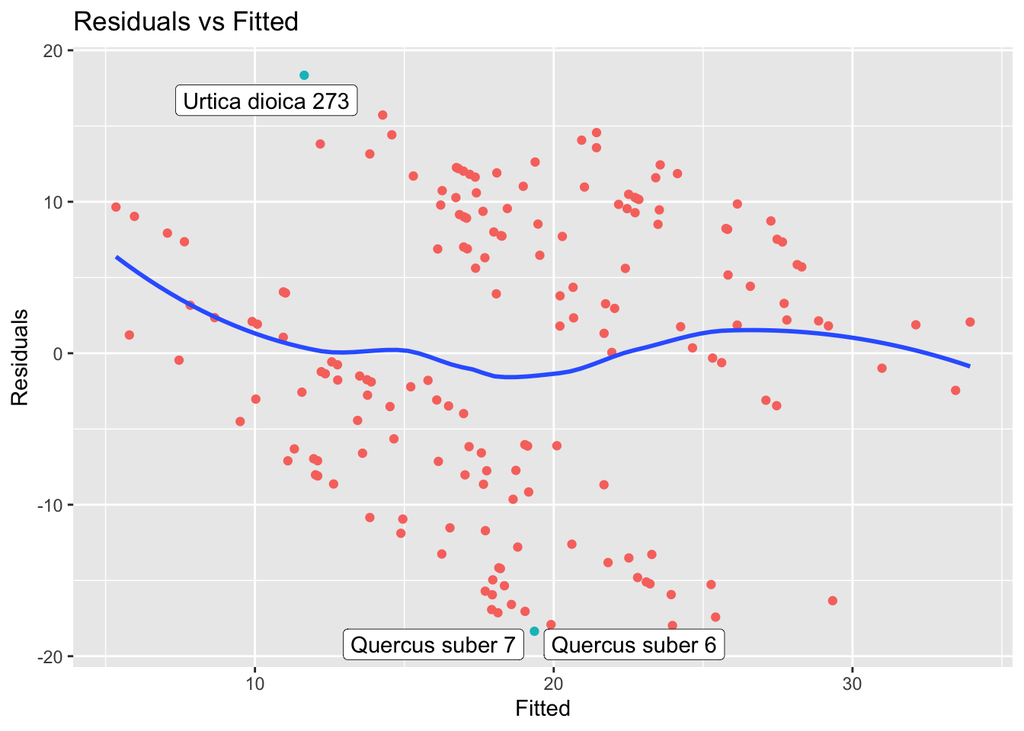

```r
high <- max(as.integer(fit$residuals))
low  <- min(as.integer(fit$residuals))
data.frame(
    x      = fit$fitted.values,
    y      = fit$residuals,
    labels = names(fit$residuals)
) |> ggplot(aes(x, y)) +
     geom_point(aes(color = y>=high | y<=low)) +
     geom_label_repel(
         aes(label = ifelse(y>=high | y<=low, labels, '')),
         box.padding   = .25,
         point.padding = .5,
         label.size    = .15,
         segment.color = 'gray'
     ) +
     geom_smooth(method = 'loess', formula = 'y ~ x', se = FALSE) +
     labs(x = 'Fitted', y = 'Residuals', title = 'Residuals vs Fitted') +
     theme(legend.position = 'none')
```

## 20.3 Which=2 - “Normal Q-Q”

I acknowledge that this falls short, without labeling the extreme values. I have read enough to understand the challenge - that `geom_qq` doesn’t support `aes(label)` and so it must be rendered `after_stat`. I tried - I did get labels to appear, but not the desired row names. TODO, perhaps.

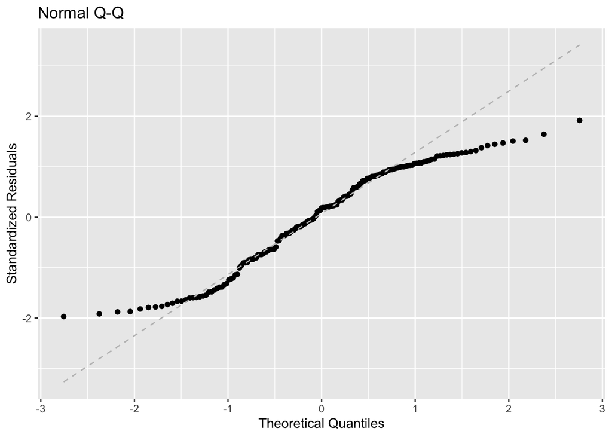

```r
data.frame(x = scale(fit$residuals)) |>
    ggplot(aes(sample = x)) +
    geom_qq() +
    geom_qq_line(linetype = 2, colour = 'grey') +
    labs(
        x     = 'Theoretical Quantiles',
        y     = 'Standardized Residuals',
        title = 'Normal Q-Q'
    )
```

## 20.4 Which=3 - “Scale-Location”

This seems to replicate the autoplot version well. I don’t know if I reverse-engineered the y-axis correctly but it looks correct when plotted. From the original y-axis label, `sqrt` is clearly used; and elsewhere “Standardized” has meant `scale`. To use those two together, I inferred `abs` to make all the values positive; then `center = FALSE` to keep them all positive - so that `sqrt` rendered no NAs. Once again, I don’t know how the threshold is calculated. (Come to think of it, I wonder what is meant by the title, specifically what is meant by “Location”.)

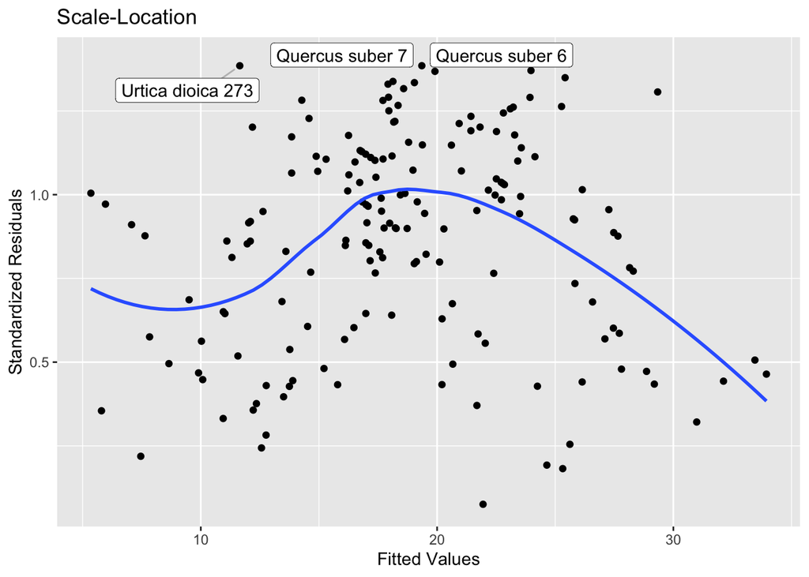

```r
thresh <- 1.38  # top three are 1.403895, 1.385063, 1.38496
data.frame(
    y      = sqrt(scale(abs(fit$residuals), center=FALSE)),
    x      = fit$fitted.values,
    labels = rownames(train)
) |> ggplot(aes(x, y)) +
     geom_point() +
     geom_smooth(method = 'loess', formula = 'y ~ x', se = FALSE) +
     geom_label_repel(
         aes(label = ifelse(y>=thresh, labels, '')),
         box.padding   = .25,
         point.padding = .5,
         label.size    = .15,
         segment.color = 'gray',
         max.overlaps  = 100
     ) +
     labs(x = 'Fitted Values', y = "Standardized Residuals", title = "Scale-Location")
```

## 20.5 Which=4 - “Cook’s Distance”

This is very close, though the threshold formula from [RPubs](https://rpubs.com/DragonflyStats/Cooks-Distance) is apparently lower than whatever is used via autoplot.

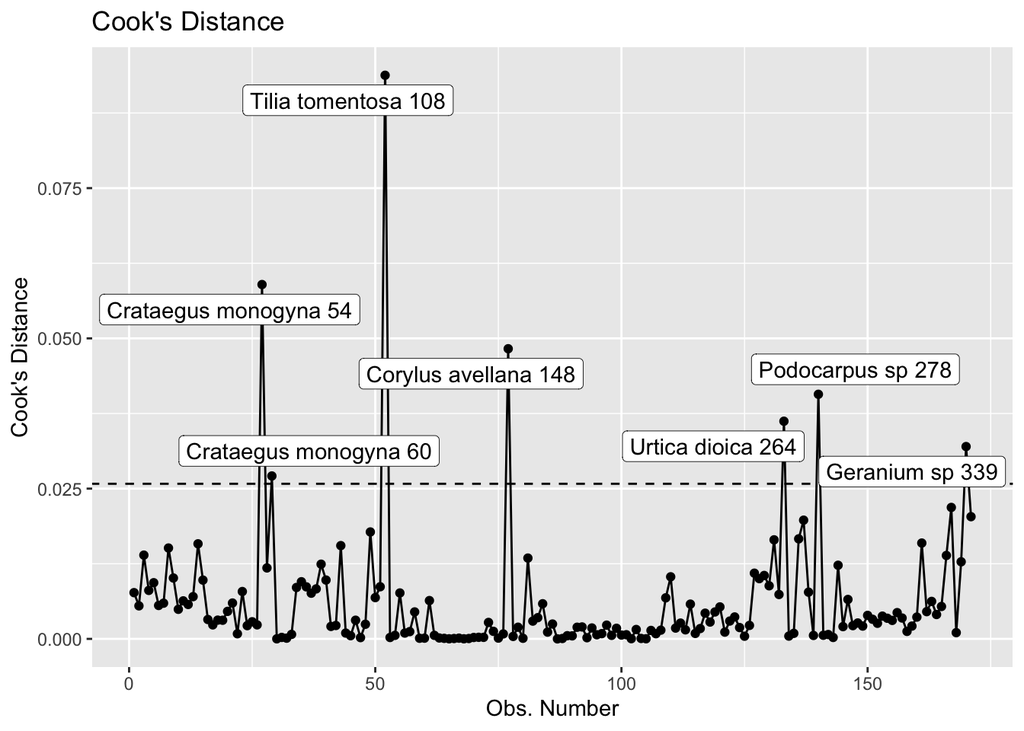

```r
thresh = 4/(nrow(train) - ncol(train) - 1)
data.frame(
    y      = cooks.distance(fit),
    x      = 1:nrow(train),
    labels = rownames(train)
) |> ggplot(aes(x, y)) +
     geom_point() +
     geom_line() +
     geom_abline(intercept = thresh, slope = 0, linetype = 2) +
     geom_label_repel(
         aes(label = ifelse(y>thresh, labels, '')),
         box.padding   = .25,
         point.padding = .5,
         label.size    = .15,
         segment.color = 'gray',
         max.overlaps  = 100
     ) +
     labs(x = 'Obs. Number', y = "Cook's Distance", title = "Cook's Distance")
```

## 20.6 Which=5 - “Residuals vs Leverage”

This is close, though I haven’t a clue what the highlighting threshold might be - and thus I have no coloring/labeling in place.

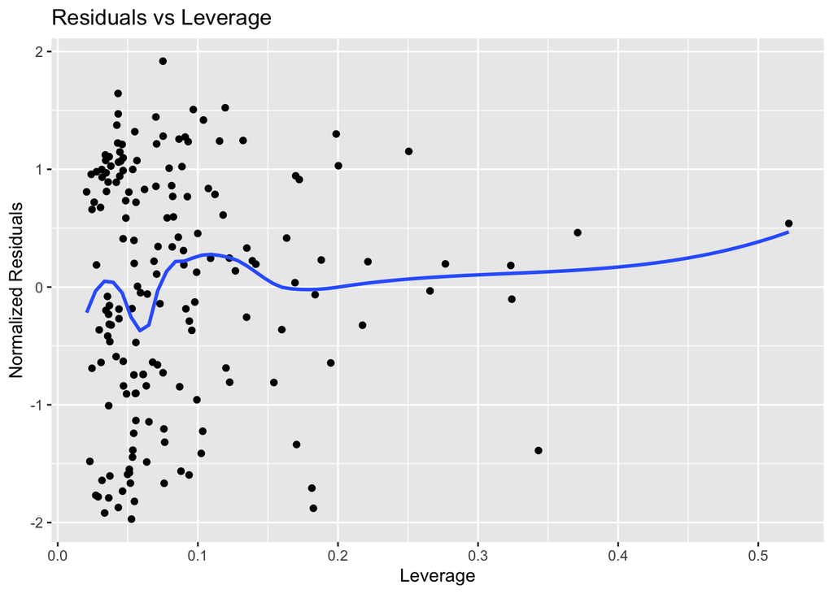

```r
data.frame(
    x = hatvalues(fit),
    y = scale(fit$residuals)
) |> ggplot(aes(x, y)) +
     geom_point() +
     stat_smooth(method = 'loess', formula = 'y ~ x', se = FALSE, span = .6) +
     labs(x = 'Leverage', y = 'Normalized Residuals', title = 'Residuals vs Leverage')
```

## 20.7 Which=6 - “Cook’s Distance vs Leverage”

Once again, clueless as to the threshold. And I cannot guess what the dashed vertical lines are in the original. Otherwise this is close.

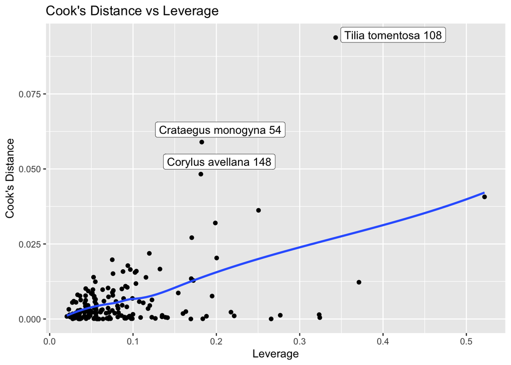

```r
thresh = .045
data.frame(
    y      = cooks.distance(fit),
    x      = hatvalues(fit),
    labels = rownames(train)
) |> ggplot(aes(x, y)) +
     geom_point() +
     geom_smooth(method = 'loess', formula = 'y ~ x', se = FALSE) +
     geom_label_repel(
         aes(label = ifelse(y>thresh, labels, '')),
         box.padding   = .25,
         point.padding = .5,
         label.size    = .15,
         segment.color = 'gray',
         max.overlaps  = 100
     ) +
     labs(x = 'Leverage', y = "Cook's Distance", title = "Cook's Distance vs Leverage")
```